# Stroke Dataset

Hunter Blum, Ben Earnest, Andrew Pak Kim

4/12/2022

Dataset:

https://www.kaggle.com/datasets/fedesoriano/stroke-prediction-dataset

# Libraries

```r
library(tidyverse)
library(caret)
library(NeuralNetTools)
library(nnet)
library(doParallel)
library(DataExplorer)
library(Boruta)
```

```r
library(rpart)
library(rpart.plot)
library(gridExtra)
library(e1071)
library(kableExtra)
set.seed(123)
```

# Data

```r
Stroke <- read.csv("stroke.csv")
```

# Multicore Support - Need to have Java Installed that is the same bit as your CPU (Probably 64)

```r
registerDoParallel()
getDoParWorkers()
```

```
## [1] 3
```

# Cleaning the Data

The data is pretty clean after running this code. All variables are the correct type after running it. The only variable missing data is BMI, which only has 200/5100 observations missing.

## Structure

```r
str(Stroke)
```

```
## 'data.frame':    5110 obs. of  12 variables:
##  $ id               : int  9046 51676 31112 60182 1665 56669 53882 10434 27419 60491 ...
##  $ gender           : chr  "Male" "Female" "Male" "Female" ...
##  $ age              : num  67 61 80 49 79 81 74 69 59 78 ...
##  $ hypertension     : int  0 0 0 0 1 0 1 0 0 0 ...
##  $ heart_disease    : int  1 0 1 0 0 0 1 0 0 0 ...
##  $ ever_married     : chr  "Yes" "Yes" "Yes" "Yes" ...
##  $ work_type        : chr  "Private" "Self-employed" "Private" "Private" ...
##  $ Residence_type   : chr  "Urban" "Rural" "Rural" "Urban" ...
##  $ avg_glucose_level: num  229 202 106 171 174 ...
##  $ bmi              : chr  "36.6" "N/A" "32.5" "34.4" ...
##  $ smoking_status   : chr  "formerly smoked" "never smoked" "never smoked" "smokes" ...
##  $ stroke           : int  1 1 1 1 1 1 1 1 1 1 ...
```

```r
#Get rid of one other observation in gender
Stroke <- Stroke %>% filter(gender!="Other")

#Fix specific variables
Stroke$hypertension <- as.factor(Stroke$hypertension)
Stroke$heart_disease <- as.factor(Stroke$heart_disease)
Stroke$bmi <- as.numeric(Stroke$bmi)
Stroke$stroke <- as.factor(Stroke$stroke)

#Make all character variables into factors
Stroke[sapply(Stroke, is.character)] <- lapply(Stroke[sapply(Stroke, is.character)], as.factor)


str(Stroke)
```

```
## 'data.frame':    5109 obs. of  12 variables:
##  $ id               : int  9046 51676 31112 60182 1665 56669 53882 10434 27419 60491 ...
##  $ gender           : Factor w/ 2 levels "Female","Male": 2 1 2 1 1 2 2 1 1 1 ...
##  $ age              : num  67 61 80 49 79 81 74 69 59 78 ...
##  $ hypertension     : Factor w/ 2 levels "0","1": 1 1 1 1 2 1 2 1 1 1 ...
##  $ heart_disease    : Factor w/ 2 levels "0","1": 2 1 2 1 1 1 2 1 1 1 ...
##  $ ever_married     : Factor w/ 2 levels "No","Yes": 2 2 2 2 2 2 2 1 2 2 ...
##  $ work_type        : Factor w/ 5 levels "children","Govt_job",..: 4 5 4 4 5 4 4 4 4 4 ...
##  $ Residence_type   : Factor w/ 2 levels "Rural","Urban": 2 1 1 2 1 2 1 2 1 2 ...
##  $ avg_glucose_level: num  229 202 106 171 174 ...
##  $ bmi              : num  36.6 NA 32.5 34.4 24 29 27.4 22.8 NA 24.2 ...
##  $ smoking_status   : Factor w/ 4 levels "formerly smoked",..: 1 2 2 3 2 1 2 2 4 4 ...
##  $ stroke           : Factor w/ 2 levels "0","1": 2 2 2 2 2 2 2 2 2 2 ...
```

```r
#Rename Factors for Easier Understanding
levels(Stroke$hypertension) <- c("No", "Yes")
levels(Stroke$heart_disease) <- c("No", "Yes")
levels(Stroke$stroke) <- c("No", "Yes")

#Get Rid of id
Stroke$id <- NULL
```

## NAs

```r
Stroke %>%
  select(everything()) %>%
  summarise_all(funs(sum(is.na(.))))
```

```
##   gender age hypertension heart_disease ever_married work_type Residence_type
## 1      0   0            0             0            0         0              0
##   avg_glucose_level bmi smoking_status stroke
## 1                 0 201              0      0
```

```r
#Just 201 missing observations in bmi

#We'll just delete the NAs for now
Stroke_clean <- na.omit(Stroke)
```

# Exploratory Data Analysis

Our target feature is stroke, where 1 indicates that a stroke occurred. For any binary attributes 1 is always the variable occurred (eg. 1 for heart disease means the patient had heart disease).

## Dataset Overview

```r
summary(Stroke_clean)
```

```
##     gender          age        hypertension heart_disease ever_married
##  Female:2897   Min.   : 0.08   No :4457     No :4665      No :1704
##  Male  :2011   1st Qu.:25.00   Yes: 451     Yes: 243      Yes:3204
##                Median :44.00
##                Mean   :42.87
##                3rd Qu.:60.00
##                Max.   :82.00
##          work_type    Residence_type avg_glucose_level      bmi
##  children     : 671   Rural:2418     Min.   : 55.12    Min.   :10.30
##  Govt_job     : 630   Urban:2490     1st Qu.: 77.07    1st Qu.:23.50
##  Never_worked :  22                  Median : 91.68    Median :28.10
##  Private      :2810                  Mean   :105.30    Mean   :28.89
##  Self-employed: 775                  3rd Qu.:113.50    3rd Qu.:33.10
##                                      Max.   :271.74    Max.   :97.60
##          smoking_status stroke
##  formerly smoked: 836   No :4699
##  never smoked   :1852   Yes: 209
##  smokes         : 737
##  Unknown        :1483
##
##
```

```r
head(Stroke_clean)
```

```
##   gender age hypertension heart_disease ever_married     work_type
## 1   Male  67           No           Yes          Yes       Private
## 3   Male  80           No           Yes          Yes       Private
## 4 Female  49           No            No          Yes       Private
## 5 Female  79          Yes            No          Yes Self-employed
## 6   Male  81           No            No          Yes       Private
## 7   Male  74          Yes           Yes          Yes       Private
##   Residence_type avg_glucose_level  bmi  smoking_status stroke
## 1          Urban            228.69 36.6 formerly smoked    Yes
## 3          Rural            105.92 32.5    never smoked    Yes
## 4          Urban            171.23 34.4          smokes    Yes
## 5          Rural            174.12 24.0    never smoked    Yes
## 6          Urban            186.21 29.0 formerly smoked    Yes
## 7          Rural             70.09 27.4    never smoked    Yes
```

## Variable by Stroke

### Make Functions

```r
#Categorical
Cat_eda <- function(x, y) {
  p1 <- ggplot(Stroke_clean, aes(x={{x}})) +
    geom_bar(aes(fill=stroke) , color = "black") +
    ggtitle(paste0("Stroke with Respect to ", y)) +
    xlab(y) + ylab("Count")

  p2 <- ggplot(Stroke_clean, aes(x={{x}})) +
    geom_bar(aes(fill=stroke), position = "fill", color = "black") + ggtitle(paste0("Stroke with Respect to ",y, " (Normalized)")) + xlab(y) + ylab("Count")

  plot(p1)
  plot(p2)
}

#Numeric
Num_eda <- function(x, y) {
  p1 <- ggplot(Stroke_clean, aes(x={{x}})) +
    geom_histogram(aes(fill=stroke), color = "black") +
    ggtitle(paste0("Stroke with Respect to ", y)) +
    xlab(y) + ylab("Count")

 p2 <- ggplot(Stroke_clean, aes(x={{x}})) +
   geom_histogram(aes(fill=stroke), color = "black", position =      "fill") +
   ggtitle(paste0("Stroke with Respect to ", y)) +
   xlab(y) + ylab("Count")

 plot(p1)
 plot(p2)

}
```

### Categorical Variables

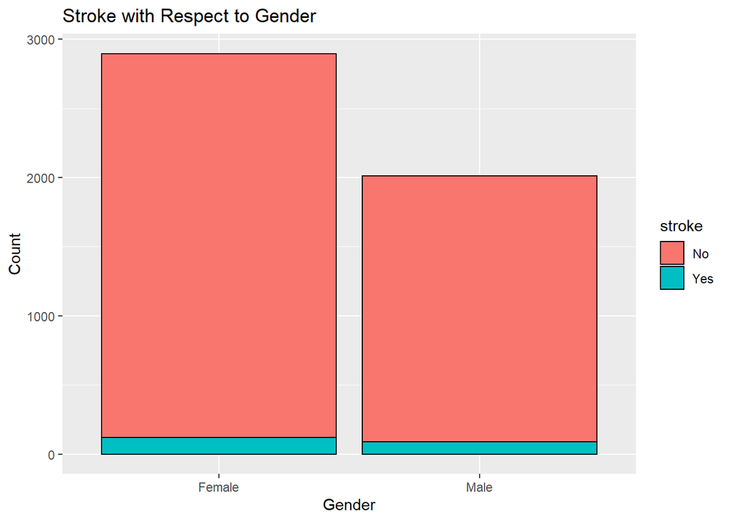

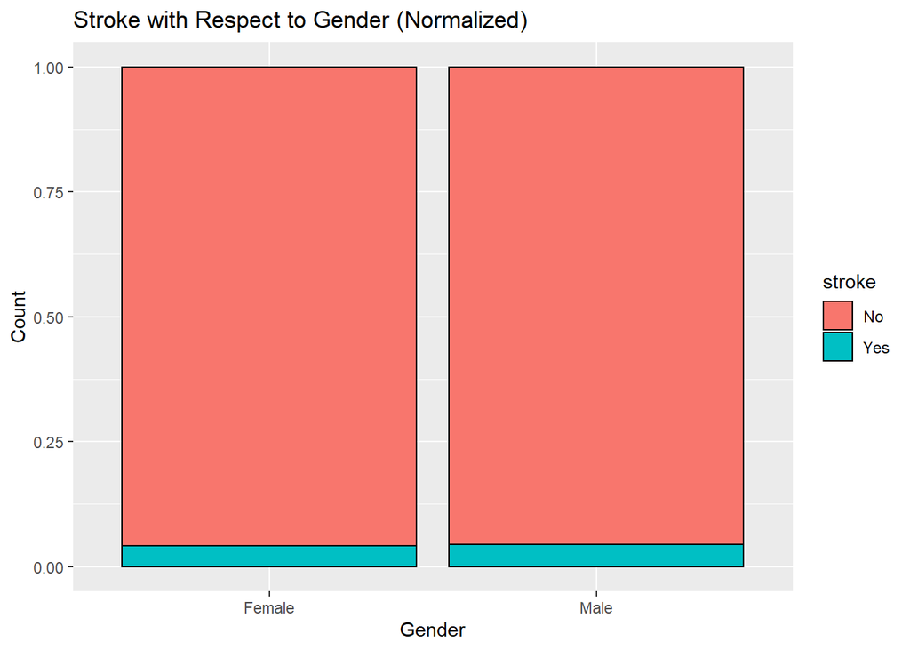

```r
Cat_eda(gender, "Gender")
```

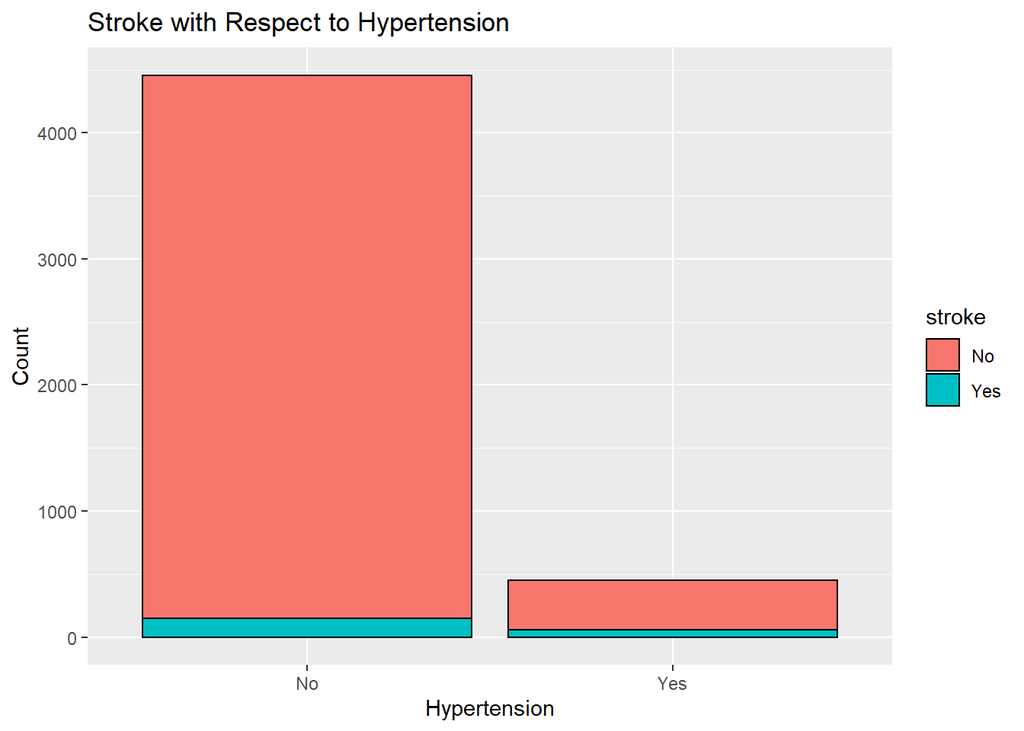

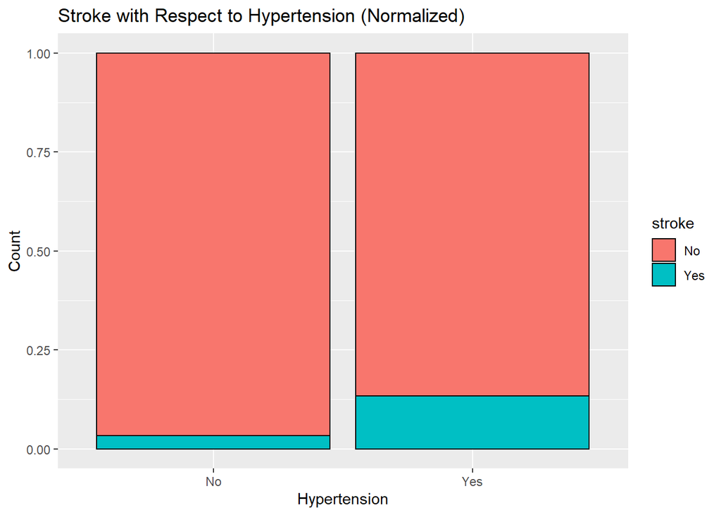

```r
Cat_eda(hypertension, "Hypertension")
```

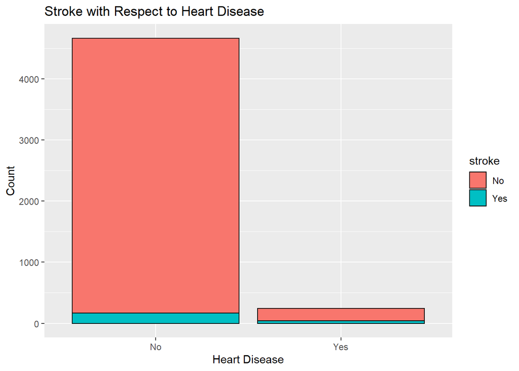

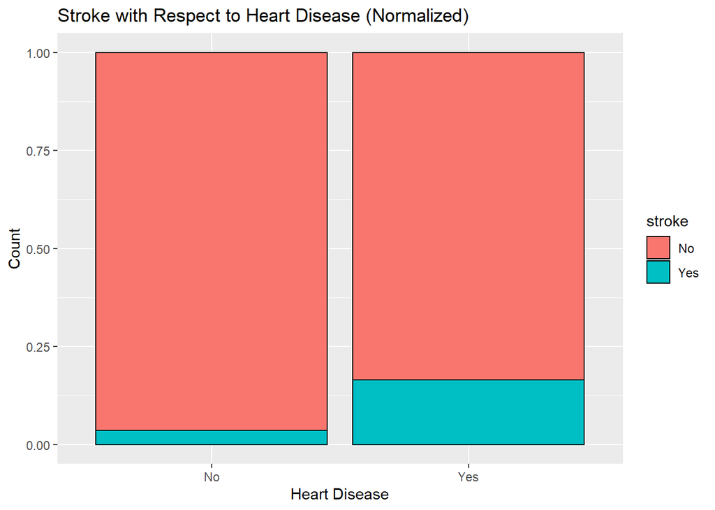

```r
Cat_eda(heart_disease, "Heart Disease")
```

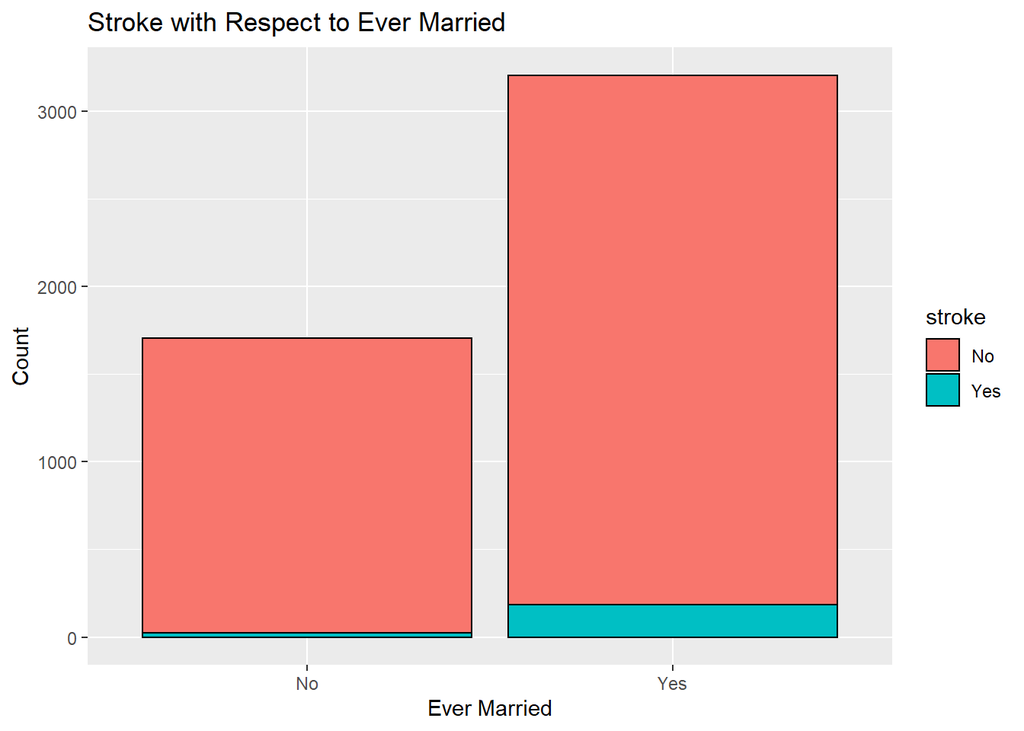

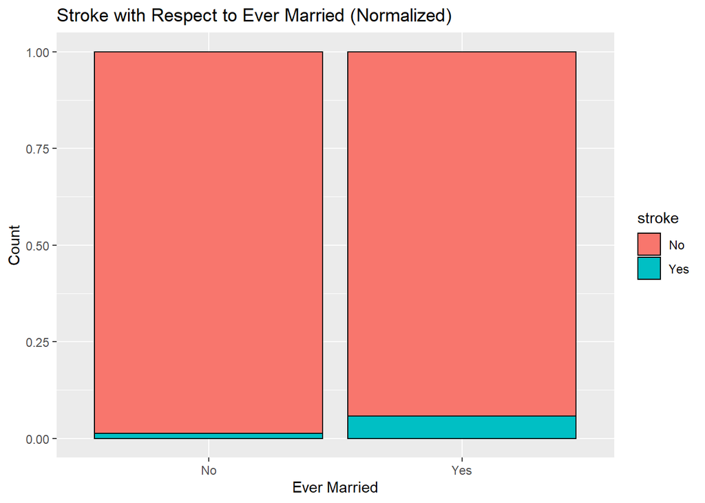

```r
Cat_eda(ever_married, "Ever Married")
```

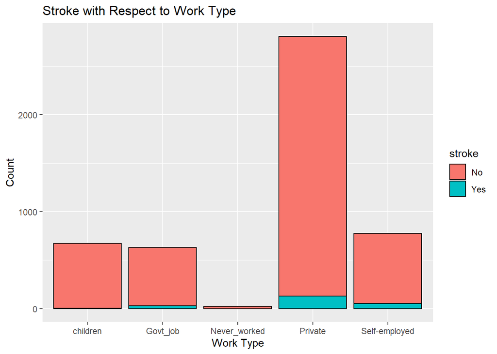

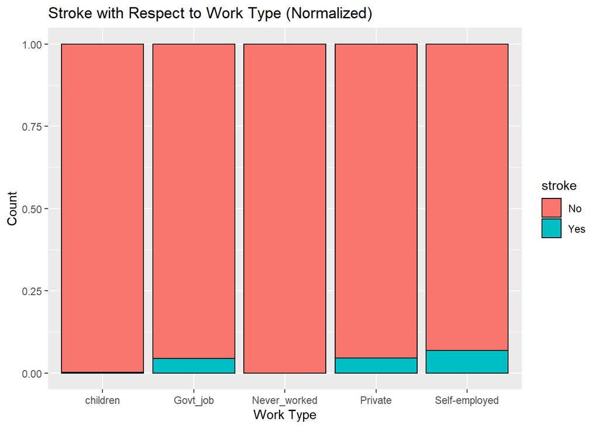

```r
Cat_eda(work_type, "Work Type")
```

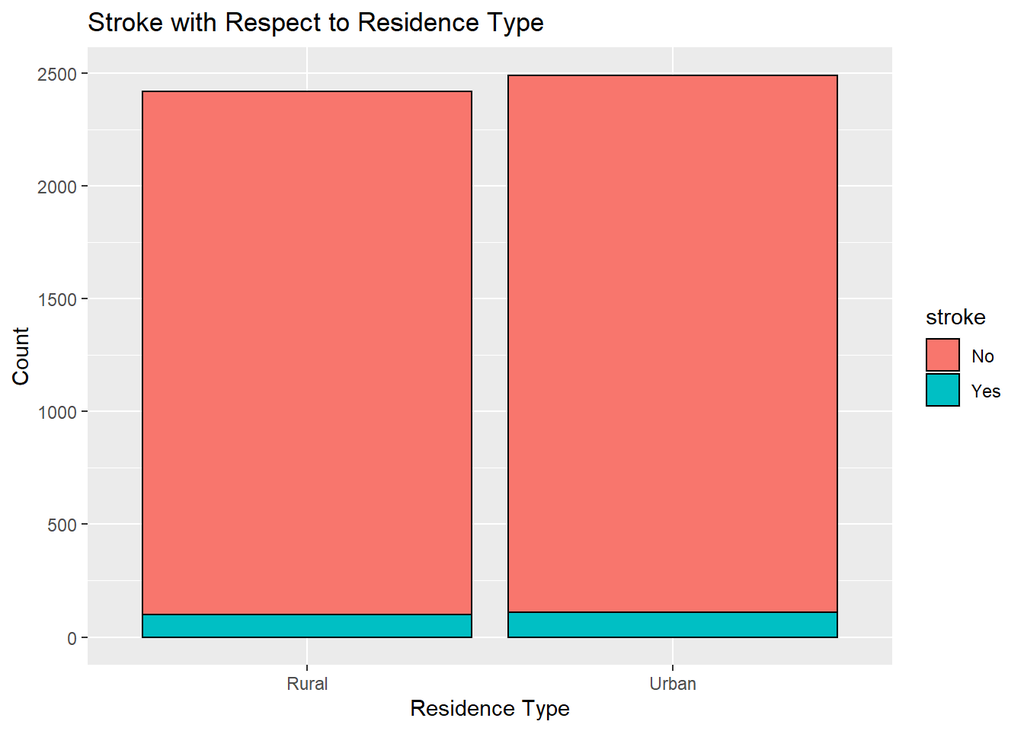

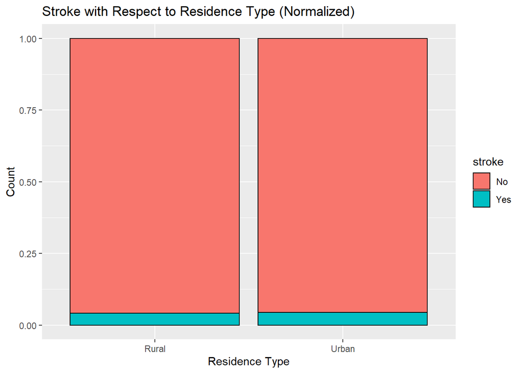

```r
Cat_eda(Residence_type, "Residence Type")
```

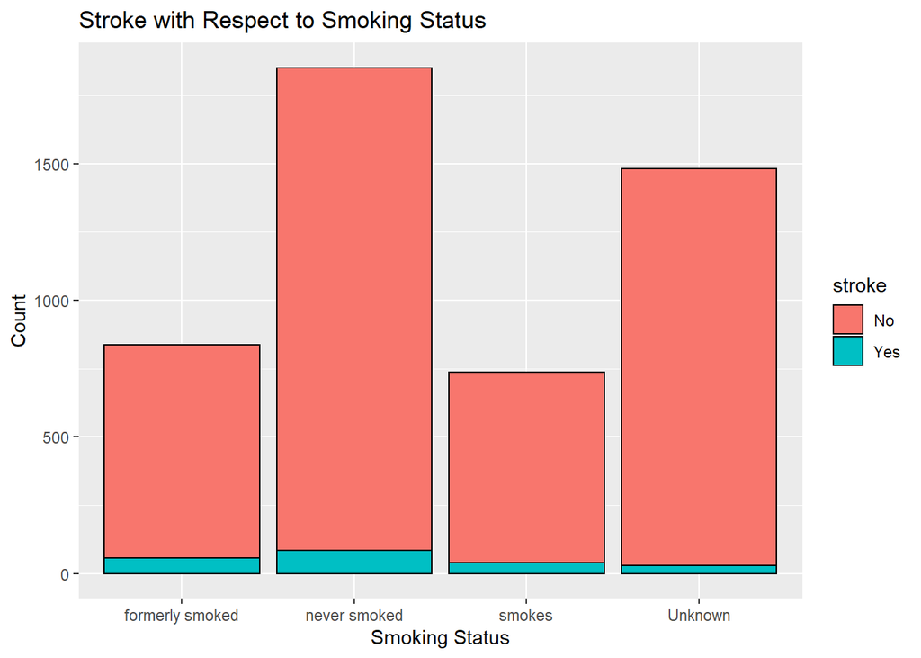

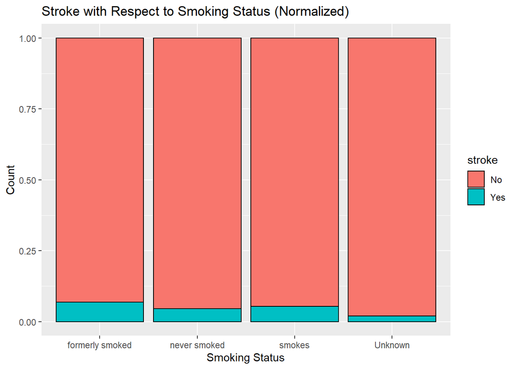

```r
Cat_eda(smoking_status, "Smoking Status")
```

### Numeric variables

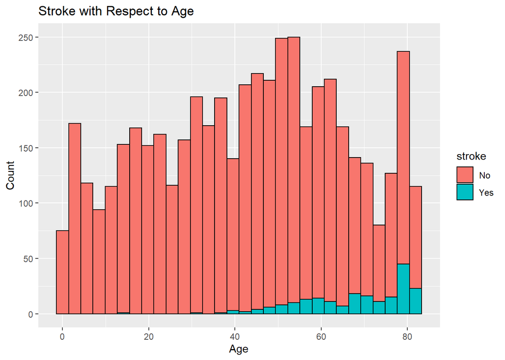

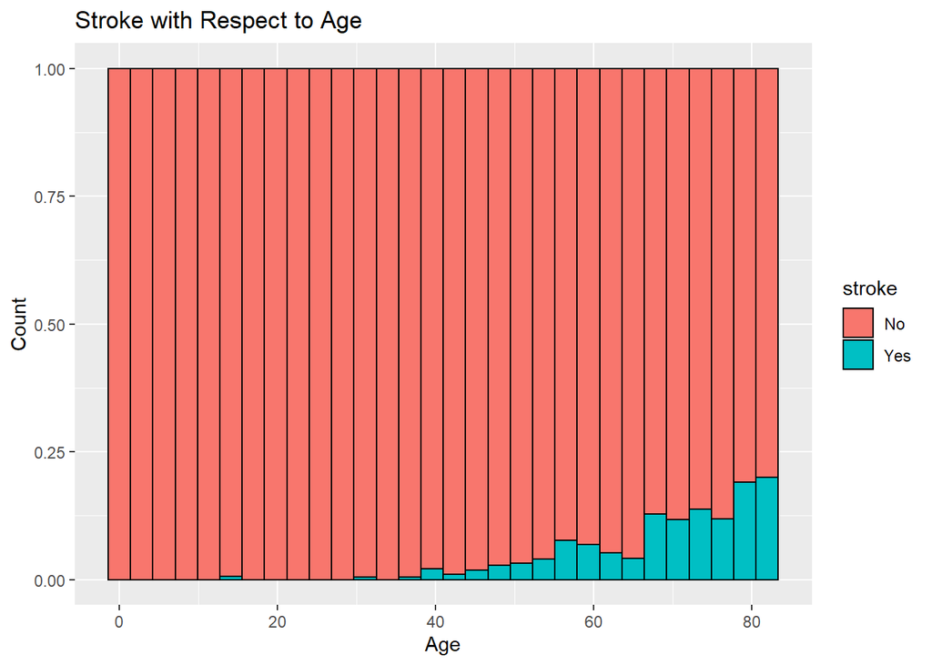

```r
Num_eda(age, "Age")
```

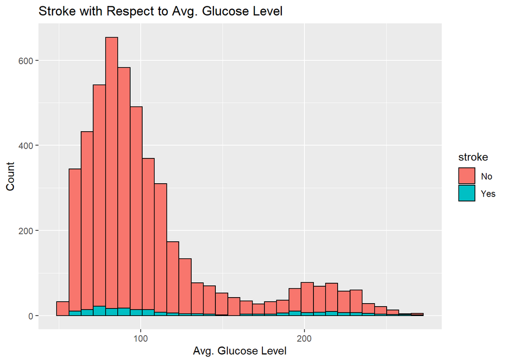

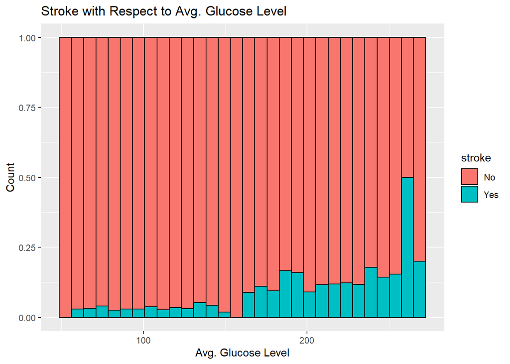

```r
Num_eda(avg_glucose_level, "Avg. Glucose Level")
```

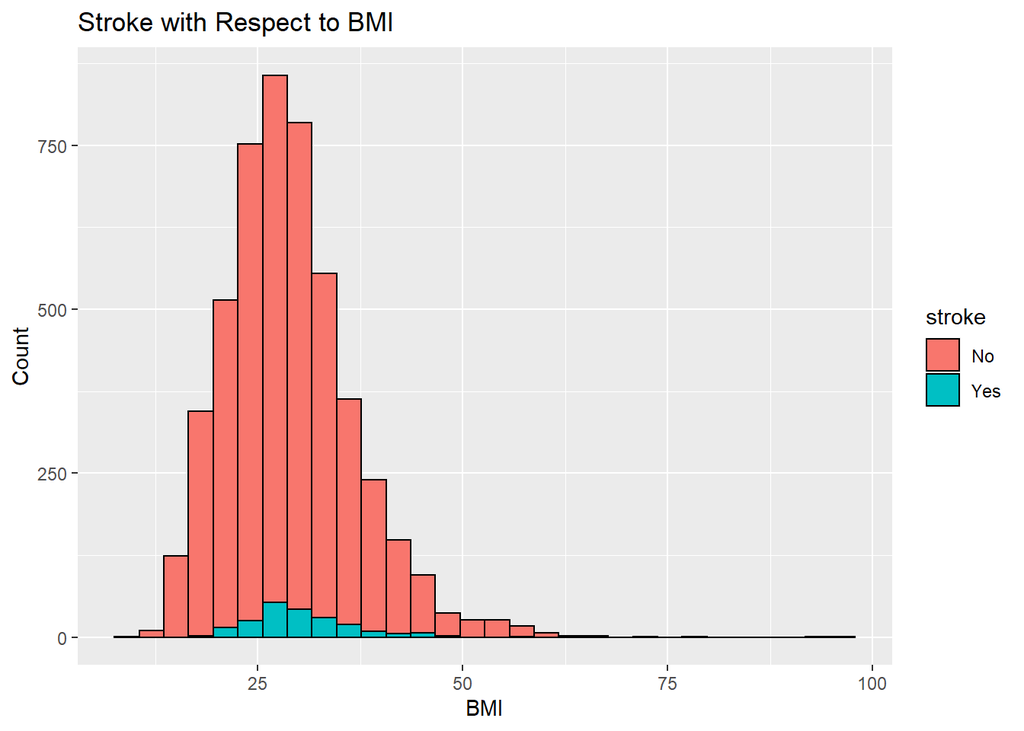

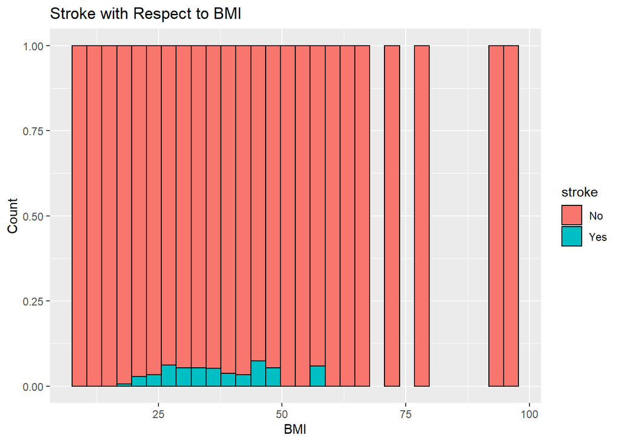

```r
Num_eda(bmi, "BMI")
```

### Correlation Matrix

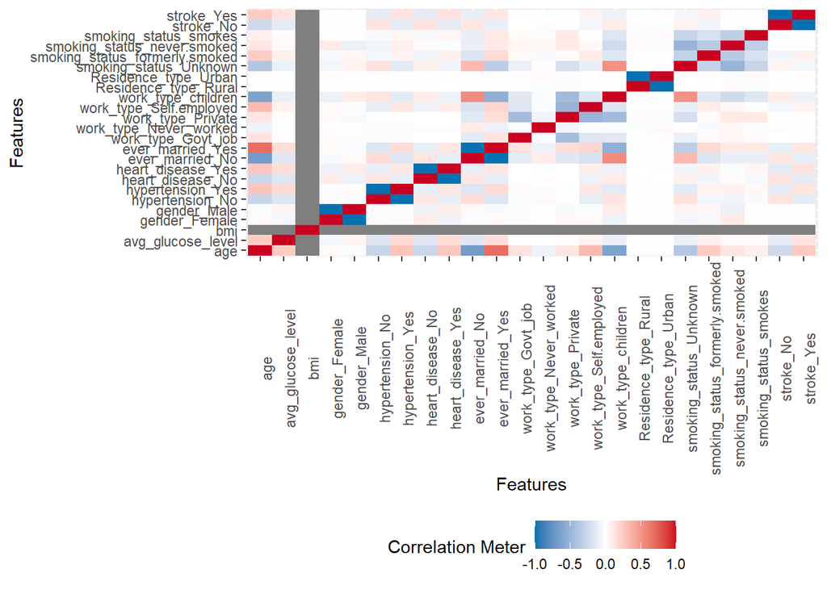

```r
plot_correlation(Stroke)
```

# Data Preparation for modelling

## Partition Data

```r
#Partition Data
trainIndex <- createDataPartition(y=Stroke_clean$stroke, p=0.8, list = F, times = 1)

Stroke_tr <- Stroke_clean[trainIndex, ]
Stroke_test <- Stroke_clean[-trainIndex, ]
```

### Visualize Stroke Balance in Training

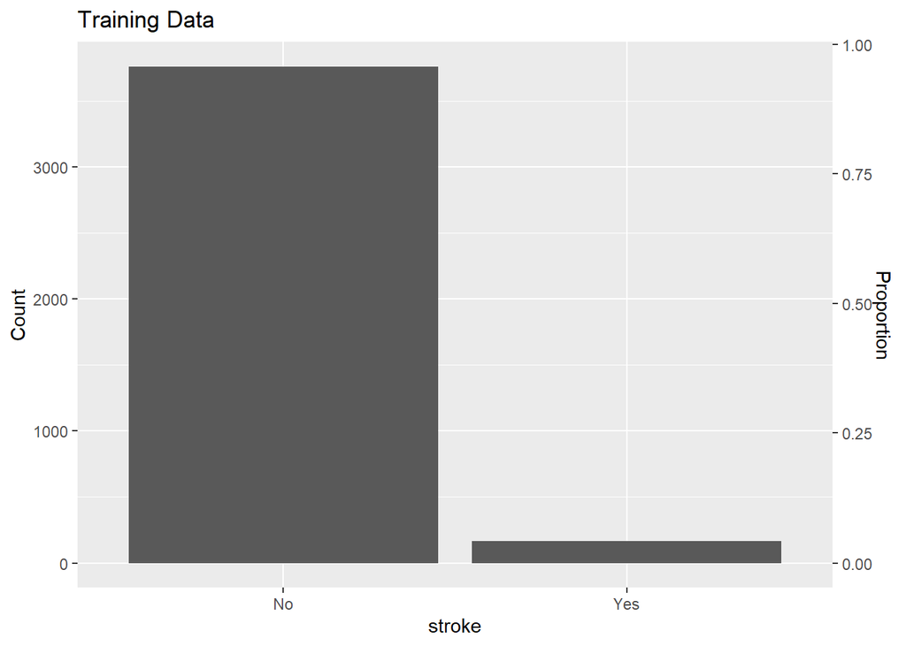

```r
#Dual Axis
ggplot(Stroke_tr, aes(x=stroke)) +
  geom_bar() +
  scale_y_continuous(
    name = "Count",
    sec.axis = sec_axis(~./nrow(Stroke_tr), name = "Proportion")
  ) + ggtitle("Training Data")
```

### Oversampling

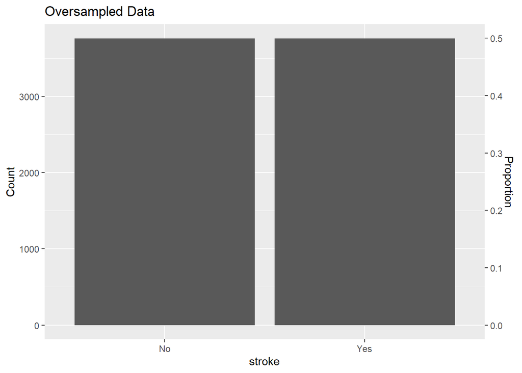

```r
#Get count of yes in training
minority <- Stroke_tr %>% group_by(stroke) %>% tally() %>% filter(stroke =="Yes")

#Change this to change balance to desired yes proportion
increase_to <- 0.5

#Calculate resample amouunt
oversample_n <- (increase_to*nrow(Stroke_tr)-minority$n)/(1-increase_to)

#Resample
to_oversample <- which(Stroke_tr$stroke == "Yes")
our_oversample <- sample(x = to_oversample, size = oversample_n, replace = T)
our_oversample <- Stroke_tr[our_oversample, ]
Stroke_over <- rbind(Stroke_tr, our_oversample)

#Evaluate
ggplot(Stroke_over, aes(x=stroke)) +
  geom_bar() +
  scale_y_continuous(
    name = "Count",
    sec.axis = sec_axis(~./nrow(Stroke_over), name = "Proportion")
  )  + ggtitle("Oversampled Data")
```

## Standardization

### Min-Max Standardization Function - Use standard.df() to create your own data set for model if you feel standardization is necessary.

```r
#Function to Standardize One Variable
standard.mm <- function(x){
  (x - min(x)) / (max(x) - min(x))
}

#Function to Standardize all Numeric Variables in Data Frame
standard.mm.df <- function(x){
  #Split Data
  tr_num <- x %>% select(where(is.numeric))
  tr_non <- x %>% select(!where(is.numeric))

  #Run Standardization Function Across Numeric
  tr_num_mm <- apply(X = tr_num, FUN = standard.mm, MARGIN = 2)

  #Recombine
  tr_mm <- cbind(tr_non, tr_num_mm)
}
```

### Z-Score Standardization

```r
#Z-Score Function
standard.z <- function(x){
  (x-mean(x))/sd(x)
}

#Function to Standardize all Numeric Variables in Data Frame
standard.z.df <- function(x){
  #Split Data
  tr_num <- x %>% select(where(is.numeric))
  tr_non <- x %>% select(!where(is.numeric))

  #Run Standardization Function Across Numeric
  tr_num_mm <- apply(X = tr_num, FUN = standard.z, MARGIN = 2)

  #Recombine
  tr_mm <- cbind(tr_non, tr_num_mm)
}
```

### Feature Selection

```r
# Run the boruta
Stroke_over_z <- standard.z.df(Stroke_over)

boruta_out <- Boruta(stroke ~ ., data = Stroke_over_z, doTrace = 2)
```

```
##  1. run of importance source...
```

```
##  2. run of importance source...
```

```
##  3. run of importance source...
```

```
##  4. run of importance source...
```

```
##  5. run of importance source...
```

```
##  6. run of importance source...
```

```
##  7. run of importance source...
```

```
##  8. run of importance source...
```

```
##  9. run of importance source...
```

```
##  10. run of importance source...
```

```
## After 10 iterations, +20 secs:
```

```
##  confirmed 10 attributes: age, avg_glucose_level, bmi, ever_married, gender and 5 more;
```

```
##  no more attributes left.
```

```r
boruta_sig <- getSelectedAttributes(boruta_out, withTentative = T)

print(boruta_sig)
```

```
##  [1] "gender"            "hypertension"      "heart_disease"
##  [4] "ever_married"      "work_type"         "Residence_type"
##  [7] "smoking_status"    "age"               "avg_glucose_level"
## [10] "bmi"
```

```r
imps <- attStats(boruta_out)
imps2 = imps[imps$decision != 'Rejected', c('meanImp', 'decision')]
imps2[order(-imps2$meanImp), ]
```

```
##                     meanImp  decision
## age               121.07528 Confirmed
## avg_glucose_level  91.64216 Confirmed
## bmi                84.51178 Confirmed
## smoking_status     59.33260 Confirmed
## work_type          57.09723 Confirmed
## hypertension       53.04735 Confirmed
## heart_disease      47.30415 Confirmed
## Residence_type     38.55393 Confirmed
## ever_married       36.90999 Confirmed
## gender             36.01437 Confirmed
```

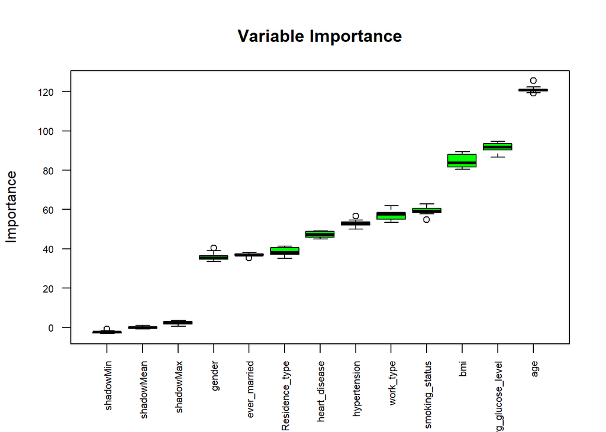

```r
plot(boruta_out, cex.axis=.7, las=2, xlab="", main="Variable Importance")
```

```r
# All Variables were deemed important
```

# Modeling

## C5.0 - Andrew

```r
library(C50)
C5 <- C5.0(formula = stroke ~ . , data = Stroke_over, control = C5.0Control(minCases = 75))
```

[figure not shown]

```r
#Visualize the tree
plot(C5)
```

```r
#Create a data frame that includes the predictor variables of the records to classify.
X = Stroke_over %>% select(!stroke)
```

```r
#Obtain model diagnostics
C5_bal <- confusionMatrix(data = predict(C5, Stroke_test), ref = Stroke_test$stroke, positive = "Yes")
C5_bal
```

```
## Confusion Matrix and Statistics
##
##           Reference
## Prediction  No Yes
##        No  747  19
##        Yes 192  22
##
##                Accuracy : 0.7847
##                  95% CI : (0.7576, 0.8101)
##     No Information Rate : 0.9582
##     P-Value [Acc > NIR] : 1
##
##                   Kappa : 0.1101
##
##  Mcnemar's Test P-Value : <2e-16
##
##             Sensitivity : 0.53659
##             Specificity : 0.79553
##          Pos Pred Value : 0.10280
##          Neg Pred Value : 0.97520
##              Prevalence : 0.04184
##          Detection Rate : 0.02245
##    Detection Prevalence : 0.21837
##       Balanced Accuracy : 0.66606
##
##        'Positive' Class : Yes
##
```

## CART - Ben

### Run CART decision tree model:

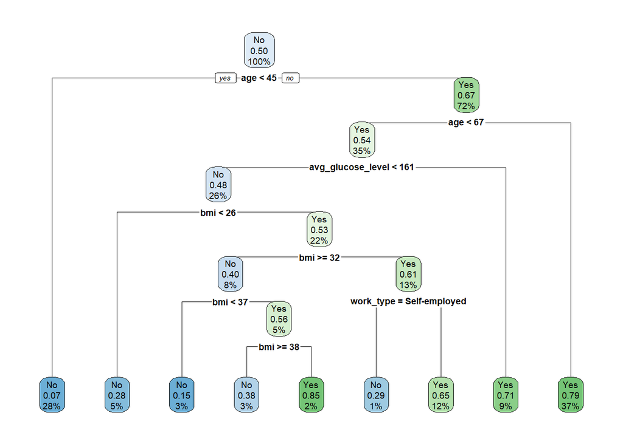

```r
cart01 <- rpart(formula = stroke ~ ., data = Stroke_over, method = "class")
rpart.plot(cart01)
```

### Evaluate Model on Train and Test Data

```r
train_cart <- confusionMatrix(data = predict(cart01, Stroke_over, type = "class"), ref = Stroke_over$stroke, positive = "Yes")
train_cart
```

```
## Confusion Matrix and Statistics
##
##           Reference
## Prediction   No  Yes
##        No  2660  408
##        Yes 1100 3352
##
##                Accuracy : 0.7995
##                  95% CI : (0.7902, 0.8085)
##     No Information Rate : 0.5
##     P-Value [Acc > NIR] : < 2.2e-16
##
##                   Kappa : 0.5989
##
##  Mcnemar's Test P-Value : < 2.2e-16
##
##             Sensitivity : 0.8915
##             Specificity : 0.7074
##          Pos Pred Value : 0.7529
##          Neg Pred Value : 0.8670
##              Prevalence : 0.5000
##          Detection Rate : 0.4457
##    Detection Prevalence : 0.5920
##       Balanced Accuracy : 0.7995
##
##        'Positive' Class : Yes
##
```

```r
cart_bal <- confusionMatrix(data = predict(cart01, Stroke_test, type = "class"), ref = Stroke_test$stroke, positive = "Yes")
cart_bal
```

```
## Confusion Matrix and Statistics
##
##           Reference
## Prediction  No Yes
##        No  649   4
##        Yes 290  37
##
##                Accuracy : 0.7
##                  95% CI : (0.6702, 0.7286)
##     No Information Rate : 0.9582
##     P-Value [Acc > NIR] : 1
##
##                   Kappa : 0.1369
##
##  Mcnemar's Test P-Value : <2e-16
##
##             Sensitivity : 0.90244
##             Specificity : 0.69116
##          Pos Pred Value : 0.11315
##          Neg Pred Value : 0.99387
##              Prevalence : 0.04184
##          Detection Rate : 0.03776
##    Detection Prevalence : 0.33367
##       Balanced Accuracy : 0.79680
##
##        'Positive' Class : Yes
##
```

### Cost Sensitive CARET -

Probably only useful if we want to hyperfocus on sensitivity, but loses a lot of specificity.

```r
cost <- matrix(c(
  0, 1,
  10, 0
), byrow = TRUE, nrow = 2)
cost
```

```
##      [,1] [,2]
## [1,]    0    1
## [2,]   10    0
```

### Create cost sensitive model

```r
train <- createFolds(Stroke_tr$stroke, k=10)

cart_stroke <- caret::train(stroke~., method="rpart", data = Stroke_tr, tuneLength = 5, parms = list(loss = cost),trControl = trainControl(
  method = "cv", indexOut = train
))

cart_stroke
```

```
## CART
##
## 3928 samples
##   10 predictor
##    2 classes: 'No', 'Yes'
##
## No pre-processing
## Resampling: Cross-Validated (10 fold)
## Summary of sample sizes: 3536, 3535, 3535, 3535, 3535, 3535, ...
## Resampling results across tuning parameters:
##
##   cp            Accuracy   Kappa
##   0.0000000000  0.8971452  0.3854536
##   0.0008267196  0.8951109  0.3804238
##   0.0016534392  0.8956191  0.3802099
##   0.0024801587  0.8943410  0.3792570
##   0.0033068783  0.8984149  0.3785458
##
## Accuracy was used to select the optimal model using the largest value.
## The final value used for the model was cp = 0.003306878.
```

```r
cart_stroke_bal <- caret::train(stroke~., method="rpart", data = Stroke_over, tuneLength = 5, parms = list(loss = cost),trControl = trainControl(
  method = "cv", indexOut = train
))

cart_stroke_bal
```

```
## CART
##
## 7520 samples
##   10 predictor
##    2 classes: 'No', 'Yes'
##
## No pre-processing
## Resampling: Cross-Validated (10 fold)
## Summary of sample sizes: 6768, 6768, 6768, 6768, 6768, 6768, ...
## Resampling results across tuning parameters:
##
##   cp           Accuracy    Kappa
##   0.007978723  0.56365737  0.09491299
##   0.011436170  0.52649231  0.08103147
##   0.013696809  0.51783183  0.07830490
##   0.018882979  0.51528730  0.07762580
##   0.484574468  0.04276886  0.00000000
##
## Accuracy was used to select the optimal model using the largest value.
## The final value used for the model was cp = 0.007978723.
```

### Evaluate

```r
cart_cost <- confusionMatrix(data = predict(cart_stroke, Stroke_test), ref = Stroke_test$stroke, positive = "Yes")
cart_cost
```

```
## Confusion Matrix and Statistics
##
##           Reference
## Prediction  No Yes
##        No  808  20
##        Yes 131  21
##
##                Accuracy : 0.8459
##                  95% CI : (0.8218, 0.868)
##     No Information Rate : 0.9582
##     P-Value [Acc > NIR] : 1
##
##                   Kappa : 0.1624
##
##  Mcnemar's Test P-Value : <2e-16
##
##             Sensitivity : 0.51220
##             Specificity : 0.86049
##          Pos Pred Value : 0.13816
##          Neg Pred Value : 0.97585
##              Prevalence : 0.04184
##          Detection Rate : 0.02143
##    Detection Prevalence : 0.15510
##       Balanced Accuracy : 0.68634
##
##        'Positive' Class : Yes
##
```

```r
cart_cost_bal <- confusionMatrix(data = predict(cart_stroke_bal, Stroke_test), ref = Stroke_test$stroke, positive = "Yes")
cart_cost_bal
```

```
## Confusion Matrix and Statistics
##
##           Reference
## Prediction  No Yes
##        No  466   1
##        Yes 473  40
##
##                Accuracy : 0.5163
##                  95% CI : (0.4845, 0.548)
##     No Information Rate : 0.9582
##     P-Value [Acc > NIR] : 1
##
##                   Kappa : 0.0725
##
##  Mcnemar's Test P-Value : <2e-16
##
##             Sensitivity : 0.97561
##             Specificity : 0.49627
##          Pos Pred Value : 0.07797
##          Neg Pred Value : 0.99786
##              Prevalence : 0.04184
##          Detection Rate : 0.04082
##    Detection Prevalence : 0.52347
##       Balanced Accuracy : 0.73594
##
##        'Positive' Class : Yes
##
```

## Logistic Regression - Ben

```r
#unbalanced
Stroke_tr_z_lr <- standard.z.df(Stroke_tr)
logreg_stroke <- glm(formula = stroke ~ ., data = Stroke_tr_z_lr, family = binomial)
summary(logreg_stroke)
```

```
##
## Call:
## glm(formula = stroke ~ ., family = binomial, data = Stroke_tr_z_lr)
##
## Deviance Residuals:
##     Min       1Q   Median       3Q      Max
## -1.2010  -0.2952  -0.1626  -0.0815   3.5082
##
## Coefficients:
##                              Estimate Std. Error z value Pr(>|z|)
## (Intercept)                 -3.700489   1.074733  -3.443 0.000575 ***
## genderMale                  -0.028491   0.172729  -0.165 0.868985
## hypertensionYes              0.629895   0.194744   3.234 0.001219 **
## heart_diseaseYes             0.454585   0.230574   1.972 0.048662 *
## ever_marriedYes              0.030847   0.287125   0.107 0.914445
## work_typeGovt_job           -0.455028   1.132155  -0.402 0.687748
## work_typeNever_worked      -10.927599 521.627746  -0.021 0.983286
## work_typePrivate            -0.461907   1.118231  -0.413 0.679556
## work_typeSelf-employed      -0.757860   1.140530  -0.664 0.506383
## Residence_typeUrban          0.003971   0.167234   0.024 0.981055
## smoking_statusnever smoked  -0.052834   0.212144  -0.249 0.803322
## smoking_statussmokes         0.375812   0.254124   1.479 0.139180
## smoking_statusUnknown       -0.310082   0.277384  -1.118 0.263618
## age                          1.457749   0.155625   9.367  < 2e-16 ***
## avg_glucose_level            0.248710   0.063996   3.886 0.000102 ***
## bmi                         -0.036858   0.103632  -0.356 0.722097
## ---
## Signif. codes:  0 '***' 0.001 '**' 0.01 '*' 0.05 '.' 0.1 ' ' 1
##
## (Dispersion parameter for binomial family taken to be 1)
##
##     Null deviance: 1387.8  on 3927  degrees of freedom
## Residual deviance: 1106.7  on 3912  degrees of freedom
## AIC: 1138.7
##
## Number of Fisher Scoring iterations: 15
```

```r
#balanced
Stroke_tr_z_bal_lr <- standard.z.df(Stroke_over)
logreg01_stroke <- glm(formula = stroke ~ ., data = Stroke_tr_z_bal_lr, family = binomial)
summary(logreg01_stroke)
```

```
##
## Call:
## glm(formula = stroke ~ ., family = binomial, data = Stroke_tr_z_bal_lr)
##
## Deviance Residuals:
##     Min       1Q   Median       3Q      Max
## -2.5291  -0.7329   0.1129   0.7519   2.6018
##
## Coefficients:
##                             Estimate Std. Error z value Pr(>|z|)
## (Intercept)                  0.17828    0.31070   0.574  0.56611
## genderMale                  -0.16544    0.06114  -2.706  0.00682 **
## hypertensionYes              0.73662    0.07963   9.250  < 2e-16 ***
## heart_diseaseYes             0.43637    0.10281   4.244 2.19e-05 ***
## ever_marriedYes              0.09102    0.09499   0.958  0.33797
## work_typeGovt_job           -0.39750    0.31635  -1.257  0.20893
## work_typeNever_worked      -11.65478  191.15688  -0.061  0.95138
## work_typePrivate            -0.41659    0.31145  -1.338  0.18103
## work_typeSelf-employed      -0.61030    0.32231  -1.894  0.05829 .
## Residence_typeUrban          0.10418    0.05865   1.776  0.07567 .
## smoking_statusnever smoked  -0.20604    0.07664  -2.688  0.00718 **
## smoking_statussmokes         0.25144    0.09091   2.766  0.00568 **
## smoking_statusUnknown       -0.44780    0.09344  -4.792 1.65e-06 ***
## age                          1.53390    0.05057  30.331  < 2e-16 ***
## avg_glucose_level            0.25093    0.03290   7.626 2.42e-14 ***
## bmi                          0.01968    0.03315   0.594  0.55275
## ---
## Signif. codes:  0 '***' 0.001 '**' 0.01 '*' 0.05 '.' 0.1 ' ' 1
##
## (Dispersion parameter for binomial family taken to be 1)
##
##     Null deviance: 10424.9  on 7519  degrees of freedom
## Residual deviance:  7189.3  on 7504  degrees of freedom
## AIC: 7221.3
##
## Number of Fisher Scoring iterations: 13
```

```r
head(Stroke_tr_z_bal_lr)
```

```
##    gender hypertension heart_disease ever_married     work_type Residence_type
## 1    Male           No           Yes          Yes       Private          Urban
## 3    Male           No           Yes          Yes       Private          Rural
## 5  Female          Yes            No          Yes Self-employed          Rural
## 6    Male           No            No          Yes       Private          Urban
## 7    Male          Yes           Yes          Yes       Private          Rural
## 11 Female          Yes            No          Yes       Private          Rural
##     smoking_status stroke       age avg_glucose_level         bmi
## 1  formerly smoked    Yes 0.5770671         1.9093525  0.97141531
## 3     never smoked    Yes 1.1674606        -0.2580567  0.40689722
## 5     never smoked    Yes 1.1220457         0.9459614 -0.76344518
## 6  formerly smoked    Yes 1.2128755         1.1594010 -0.07500847
## 7     never smoked    Yes 0.8949713        -0.8906076 -0.29530822
## 11    never smoked    Yes 1.2128755        -0.7080629  0.02137266
```

```r
Stroke_logreg_df <- subset(Stroke_tr_z_bal_lr, select = c("gender", "hypertension", "heart_disease", "smoking_status", "age", "avg_glucose_level", "stroke"))

logreg_stroke_subset <- glm(formula = stroke ~ ., data = Stroke_logreg_df, family = binomial)
summary(logreg_stroke_subset)
```

```
##
## Call:
## glm(formula = stroke ~ ., family = binomial, data = Stroke_logreg_df)
##
## Deviance Residuals:
##      Min        1Q    Median        3Q       Max
## -2.52959  -0.74160   0.05061   0.74884   2.68731
##
## Coefficients:
##                            Estimate Std. Error z value Pr(>|z|)
## (Intercept)                -0.12931    0.06864  -1.884  0.05958 .
## genderMale                 -0.15016    0.06076  -2.471  0.01346 *
## hypertensionYes             0.71806    0.07879   9.114  < 2e-16 ***
## heart_diseaseYes            0.45246    0.10226   4.425 9.66e-06 ***
## smoking_statusnever smoked -0.22301    0.07606  -2.932  0.00337 **
## smoking_statussmokes        0.23934    0.09033   2.650  0.00806 **
## smoking_statusUnknown      -0.42955    0.09208  -4.665 3.09e-06 ***
## age                         1.49247    0.04353  34.283  < 2e-16 ***
## avg_glucose_level           0.26549    0.03123   8.501  < 2e-16 ***
## ---
## Signif. codes:  0 '***' 0.001 '**' 0.01 '*' 0.05 '.' 0.1 ' ' 1
##
## (Dispersion parameter for binomial family taken to be 1)
##
##     Null deviance: 10424.9  on 7519  degrees of freedom
## Residual deviance:  7203.5  on 7511  degrees of freedom
## AIC: 7221.5
##
## Number of Fisher Scoring iterations: 5
```

### Compare the logreg predictions to the training dataset target variables. Covert the probabilites to binary outputs in a new column called ‘pred’ on the Stroke_logreg_df dataframe:

```r
# prediction
Stroke_logreg_df$pred_prob <- predict(object = logreg_stroke_subset, newdata = Stroke_logreg_df, type='response')
Stroke_logreg_df$pred <- (Stroke_logreg_df$pred_prob > 0.5)*1

# Change pred variables to y/n
Stroke_logreg_df$pred[Stroke_logreg_df$pred=="1"]<-"Yes"
Stroke_logreg_df$pred[Stroke_logreg_df$pred=="0"]<-"No"

# create contingency table of predicted vs. actual
logreg_t1 <- table(Stroke_logreg_df$stroke, Stroke_logreg_df$pred)
row.names(logreg_t1) <- c("Actual: No", "Actual: Yes")
colnames(logreg_t1) <- c("Predicted: No", "Predicted: Yes")
logreg_t1 <- addmargins(A = logreg_t1, FUN = list(Total = sum), quiet = TRUE)
logreg_t1.df <- as.data.frame.matrix(logreg_t1)
logreg_t1.df
```

```
##             Predicted: No Predicted: Yes Total
## Actual: No           2771            989  3760
## Actual: Yes           799           2961  3760
## Total                3570           3950  7520
```

### Evaluation metric for the logistic regression model

```r
#calculate evaluation metrics
precision_lr <- logreg_t1.df[2,2] / logreg_t1.df[3,2]
Accuracy_lr <- (logreg_t1.df[1,1] + logreg_t1.df[2,2])/logreg_t1.df[3,3]
error_rate_lr <- 1 - Accuracy_lr
sensitivity_lr <- logreg_t1.df[2,2]/logreg_t1.df[1,3]
specificity_lr <- logreg_t1.df[1,1]/logreg_t1.df[1,3]
f1_lr <- 2*((precision_lr * specificity_lr)/(precision_lr+specificity_lr))
f2_lr <- 5*((precision_lr*specificity_lr)/((4*precision_lr)+specificity_lr))
f0.5_lr <- 1.25*((precision_lr * specificity_lr)/((0.25*precision_lr)*specificity_lr))


#create dataframe for evaluation metrics
eval.dflr <- data.frame(eval.measure = c("Accuracy", "error.rate", "sensitivity", "specificity", "precision", "f1", "f2", "f0.5"))
eval.dflr$model.lr <- round(c(Accuracy_lr, error_rate_lr, sensitivity_lr, specificity_lr, precision_lr, f1_lr, f2_lr, f0.5_lr), 2)
eval.dflr
```

```
##   eval.measure model.lr
## 1     Accuracy     0.76
## 2   error.rate     0.24
## 3  sensitivity     0.79
## 4  specificity     0.74
## 5    precision     0.75
## 6           f1     0.74
## 7           f2     0.74
## 8         f0.5     5.00
```

## Random Forest - Hunter

### Create Models

```r
train <- createFolds(Stroke_tr$stroke, k=10)

rf_stroke <- caret::train(stroke~., method="rf", data = Stroke_tr, tuneLength = 5, trControl = trainControl(
  method = "cv", indexOut = train, classProbs = TRUE
))

rf_stroke
```

```
## Random Forest
##
## 3928 samples
##   10 predictor
##    2 classes: 'No', 'Yes'
##
## No pre-processing
## Resampling: Cross-Validated (10 fold)
## Summary of sample sizes: 3535, 3535, 3535, 3535, 3536, 3535, ...
## Resampling results across tuning parameters:
##
##   mtry  Accuracy   Kappa
##    2    0.9577400  0.02032707
##    5    0.9961800  0.94974337
##    8    0.9961800  0.94974337
##   11    0.9959255  0.94678592
##   15    0.9959255  0.94678592
##
## Accuracy was used to select the optimal model using the largest value.
## The final value used for the model was mtry = 5.
```

```r
train <- createFolds(Stroke_over$stroke, k=10)

rf_stroke_bal <- caret::train(stroke~., method="rf", data = Stroke_over, tuneLength = 5, trControl = trainControl(
  method = "cv", indexOut = train
))

rf_stroke_bal
```

```
## Random Forest
##
## 7520 samples
##   10 predictor
##    2 classes: 'No', 'Yes'
##
## No pre-processing
## Resampling: Cross-Validated (10 fold)
## Summary of sample sizes: 6768, 6768, 6768, 6768, 6768, 6768, ...
## Resampling results across tuning parameters:
##
##   mtry  Accuracy   Kappa
##    2    0.9047872  0.8095745
##    5    0.9990691  0.9981383
##    8    0.9989362  0.9978723
##   11    0.9988032  0.9976064
##   15    0.9988032  0.9976064
##
## Accuracy was used to select the optimal model using the largest value.
## The final value used for the model was mtry = 5.
```

### Confusion Matrices

```r
rf_reg <- confusionMatrix(data = predict(rf_stroke, Stroke_test), ref = Stroke_test$stroke, positive = "Yes")
rf_reg
```

```
## Confusion Matrix and Statistics
##
##           Reference
## Prediction  No Yes
##        No  939  41
##        Yes   0   0
##
##                Accuracy : 0.9582
##                  95% CI : (0.9437, 0.9698)
##     No Information Rate : 0.9582
##     P-Value [Acc > NIR] : 0.5414
##
##                   Kappa : 0
##
##  Mcnemar's Test P-Value : 4.185e-10
##
##             Sensitivity : 0.00000
##             Specificity : 1.00000
##          Pos Pred Value :     NaN
##          Neg Pred Value : 0.95816
##              Prevalence : 0.04184
##          Detection Rate : 0.00000
##    Detection Prevalence : 0.00000
##       Balanced Accuracy : 0.50000
##
##        'Positive' Class : Yes
##
```

```r
rf_bal <- confusionMatrix(data = predict(rf_stroke_bal, Stroke_test), ref = Stroke_test$stroke, positive = "Yes")
rf_bal
```

```
## Confusion Matrix and Statistics
##
##           Reference
## Prediction  No Yes
##        No  929  41
##        Yes  10   0
##
##                Accuracy : 0.948
##                  95% CI : (0.9321, 0.961)
##     No Information Rate : 0.9582
##     P-Value [Acc > NIR] : 0.9492
##
##                   Kappa : -0.0167
##
##  Mcnemar's Test P-Value : 2.659e-05
##
##             Sensitivity : 0.00000
##             Specificity : 0.98935
##          Pos Pred Value : 0.00000
##          Neg Pred Value : 0.95773
##              Prevalence : 0.04184
##          Detection Rate : 0.00000
##    Detection Prevalence : 0.01020
##       Balanced Accuracy : 0.49468
##
##        'Positive' Class : Yes
##
```

## Naive Bayes - Andrew

### Create the tables that will allow calculation of necessary probabilities

#### Table Function

```r
#For any individual dataset
#x = data set, y = non stroke variable
nb_table <- function(x, y) {
  gen <- table(x[,"stroke"], x[,y])
  colnames(gen) <- levels(x[,y])
  rownames(gen) <- c("stroke = Yes", "stroke = No")
  names(dimnames(gen)) <- list(" ", y)
  addmargins(A = gen, FUN = list(Total = sum), quiet = TRUE)
}
```

#### First table is the contingency table of “stroke” and “gender”. The value 1 indicates “yes” while 0 indicates “no.”

```r
nb_table(Stroke_over, "gender")
```

```
##               gender
##                Female Male Total
##   stroke = Yes   2233 1527  3760
##   stroke = No    2167 1593  3760
##   Total          4400 3120  7520
```

#### Second table is the contingency table of “stroke” and “hypertension”. The value 1 indicates “yes” while 0 indicates “no.”

```r
nb_table(Stroke_over, "hypertension")
```

```
##               hypertension
##                  No  Yes Total
##   stroke = Yes 3452  308  3760
##   stroke = No  2701 1059  3760
##   Total        6153 1367  7520
```

#### Third table is the contingency table of “stroke” and “heart disease”. The value 1 indicates “yes” while 0 indicates “no.”

```r
nb_table(Stroke_over, "heart_disease")
```

```
##               heart_disease
##                  No  Yes Total
##   stroke = Yes 3600  160  3760
##   stroke = No  3005  755  3760
##   Total        6605  915  7520
```

#### Fourth table is the contingency table of “stroke” and “ever married”.

```r
nb_table(Stroke_over, "ever_married")
```

```
##               ever_married
##                  No  Yes Total
##   stroke = Yes 1344 2416  3760
##   stroke = No   405 3355  3760
##   Total        1749 5771  7520
```

#### Fifth table is the contingency table of “stroke” and “residence type”.

```r
nb_table(Stroke_over, "Residence_type")
```

```
##               Residence_type
##                Rural Urban Total
##   stroke = Yes  1844  1916  3760
##   stroke = No   1748  2012  3760
##   Total         3592  3928  7520
```

#### Sixth table is the contingency table of “stroke” and “smoking status”.

```r
nb_table(Stroke_over, "smoking_status")
```

```
##               smoking_status
##                formerly smoked never smoked smokes Unknown Total
##   stroke = Yes             618         1399    561    1182  3760
##   stroke = No             1053         1467    749     491  3760
##   Total                   1671         2866   1310    1673  7520
```

#### Seventh table is the contingency table of “stroke” and “work type”.

```r
nb_table(Stroke_over, "work_type")
```

```
##               work_type
##                children Govt_job Never_worked Private Self-employed Total
##   stroke = Yes      532      496           21    2140           571  3760
##   stroke = No        14      587            0    2159          1000  3760
##   Total             546     1083           21    4299          1571  7520
```

### Gridlines for each variable in association with “stroke”.

#### Plot Function

```r
nb_plot <- function(x, y){
  ggplot(x, aes(stroke)) + geom_bar(aes(fill=x[,y]), position = "fill", color = "black") + ylab("Proportion") + labs(fill = y)
}
```

#### Graphs of “stroke” in association with “gender” and “hyptertension”.

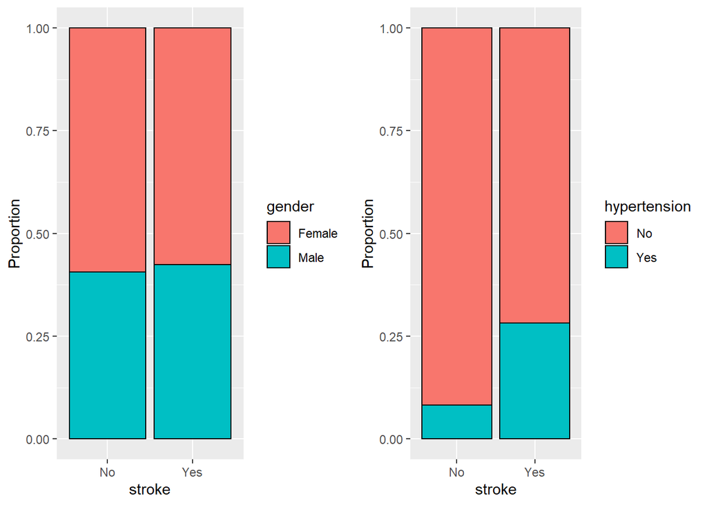

```r
grid.arrange(nb_plot(Stroke_over, "gender"), nb_plot(Stroke_over,"hypertension"), nrow = 1)
```

#### Run the Naive Bayes estimator for “stroke” in association with “gender” and “hypertension”.

```r
nb01 <- naiveBayes(formula = stroke ~ gender + hypertension, data = Stroke_over)

nb_gender <- confusionMatrix(data = predict(nb01, Stroke_test, type = "class"), ref = Stroke_test$stroke, positive = "Yes")
nb_gender
```

```
## Confusion Matrix and Statistics
##
##           Reference
## Prediction  No Yes
##        No  856  30
##        Yes  83  11
##
##                Accuracy : 0.8847
##                  95% CI : (0.863, 0.904)
##     No Information Rate : 0.9582
##     P-Value [Acc > NIR] : 1
##
##                   Kappa : 0.1112
##
##  Mcnemar's Test P-Value : 9.994e-07
##
##             Sensitivity : 0.26829
##             Specificity : 0.91161
##          Pos Pred Value : 0.11702
##          Neg Pred Value : 0.96614
##              Prevalence : 0.04184
##          Detection Rate : 0.01122
##    Detection Prevalence : 0.09592
##       Balanced Accuracy : 0.58995
##
##        'Positive' Class : Yes
##
```

#### Graphs of “stroke” in association with “heart disease” and “ever married”.

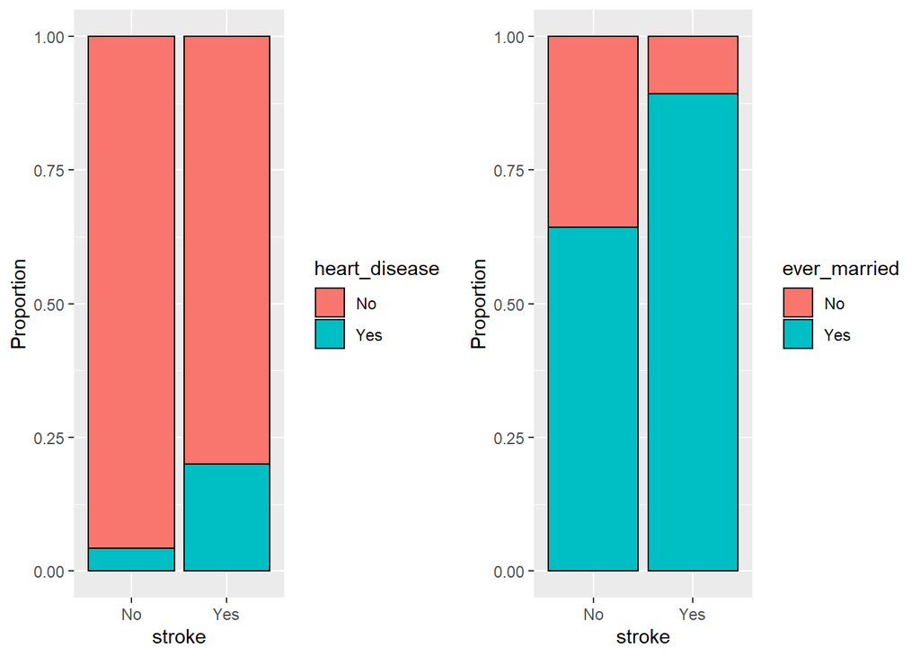

```r
grid.arrange(nb_plot(Stroke_over, "heart_disease"), nb_plot(Stroke_over,"ever_married"), nrow = 1)
```

#### Run the Naive Bayes estimator for “stroke” in association with “heart disease” and “ever married”.

```r
nb02 <- naiveBayes(formula = stroke ~ heart_disease + ever_married, data = Stroke_over)

nb_heart_marry <- confusionMatrix(data = predict(nb02, Stroke_test, type = "class"), ref = Stroke_test$stroke, positive = "Yes")
nb_heart_marry
```

```
## Confusion Matrix and Statistics
##
##           Reference
## Prediction  No Yes
##        No  332   5
##        Yes 607  36
##
##                Accuracy : 0.3755
##                  95% CI : (0.3451, 0.4067)
##     No Information Rate : 0.9582
##     P-Value [Acc > NIR] : 1
##
##                   Kappa : 0.0289
##
##  Mcnemar's Test P-Value : <2e-16
##
##             Sensitivity : 0.87805
##             Specificity : 0.35357
##          Pos Pred Value : 0.05599
##          Neg Pred Value : 0.98516
##              Prevalence : 0.04184
##          Detection Rate : 0.03673
##    Detection Prevalence : 0.65612
##       Balanced Accuracy : 0.61581
##
##        'Positive' Class : Yes
##
```

#### Graph of “stroke” in association with “Residence type”.

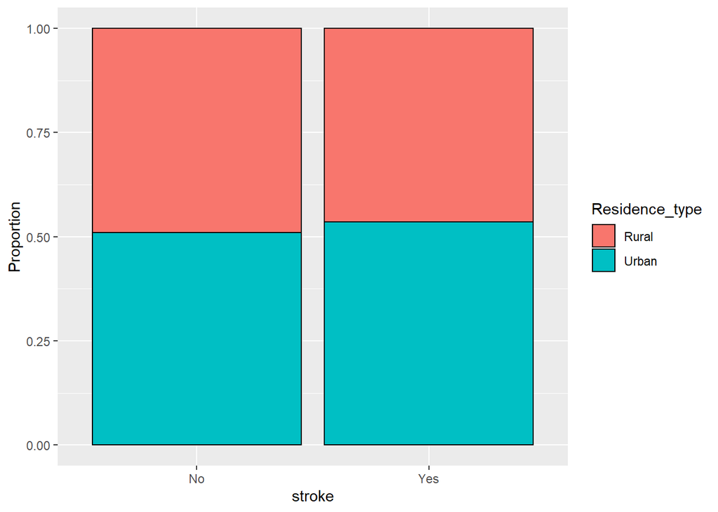

```r
grid.arrange(nb_plot(Stroke_over, "Residence_type"))
```

#### Run the Naive Bayes estimator for “stroke” in association with “Residence type”.

```r
nb03 <- naiveBayes(formula = stroke ~ Residence_type, data = Stroke_over)

nb_Res <- confusionMatrix(data = predict(nb03, Stroke_test, type = "class"), ref = Stroke_test$stroke, positive = "Yes")
nb_Res
```

```
## Confusion Matrix and Statistics
##
##           Reference
## Prediction  No Yes
##        No  474  20
##        Yes 465  21
##
##                Accuracy : 0.5051
##                  95% CI : (0.4733, 0.5369)
##     No Information Rate : 0.9582
##     P-Value [Acc > NIR] : 1
##
##                   Kappa : 0.0027
##
##  Mcnemar's Test P-Value : <2e-16
##
##             Sensitivity : 0.51220
##             Specificity : 0.50479
##          Pos Pred Value : 0.04321
##          Neg Pred Value : 0.95951
##              Prevalence : 0.04184
##          Detection Rate : 0.02143
##    Detection Prevalence : 0.49592
##       Balanced Accuracy : 0.50849
##
##        'Positive' Class : Yes
##
```

#### Graph of “stroke” in association with “smoking status” and “work type”.

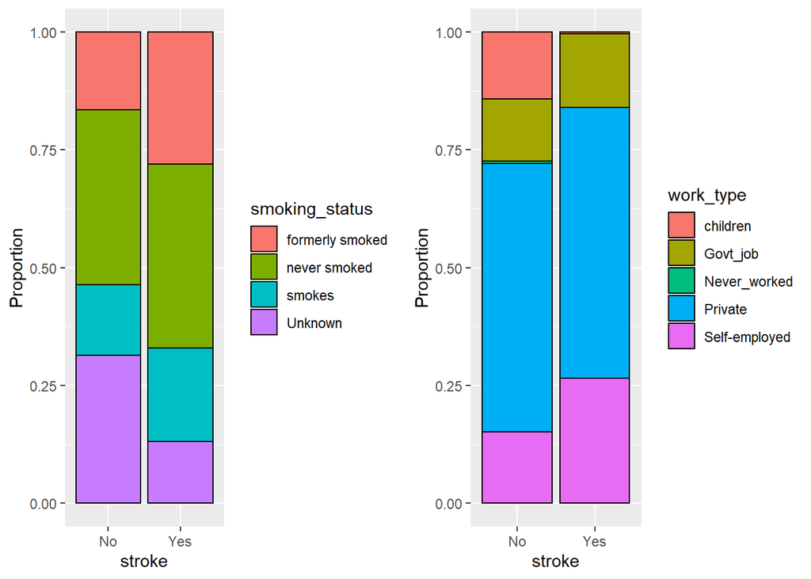

```r
grid.arrange(nb_plot(Stroke_over, "smoking_status"), nb_plot(Stroke_over, "work_type"), nrow = 1)
```

#### Run the Naive Bayes estimator for “stroke” in association with “smoking status” and “work type”.

```r
nb04 <- naiveBayes(formula = stroke ~ smoking_status + work_type, data = Stroke_over)

nb_smoke_work <- confusionMatrix(data = predict(nb04, Stroke_test, type = "class"), ref = Stroke_test$stroke, positive = "Yes")
nb_smoke_work
```

```
## Confusion Matrix and Statistics
##
##           Reference
## Prediction  No Yes
##        No  288   6
##        Yes 651  35
##
##                Accuracy : 0.3296
##                  95% CI : (0.3002, 0.36)
##     No Information Rate : 0.9582
##     P-Value [Acc > NIR] : 1
##
##                   Kappa : 0.0188
##
##  Mcnemar's Test P-Value : <2e-16
##
##             Sensitivity : 0.85366
##             Specificity : 0.30671
##          Pos Pred Value : 0.05102
##          Neg Pred Value : 0.97959
##              Prevalence : 0.04184
##          Detection Rate : 0.03571
##    Detection Prevalence : 0.70000
##       Balanced Accuracy : 0.58018
##
##        'Positive' Class : Yes
##
```

## Neural Network - Hunter

### Fitting Models

```r
#Unbalanced
train <- createFolds(Stroke_tr$stroke, k=10)

nnet_stroke <- caret::train(stroke ~ ., method = "nnet", data = Stroke_tr,
    tuneLength = 5,
    trControl = trainControl(
        method = "cv", indexOut = train),
  trace = FALSE)

nnet_stroke
```

```
## Neural Network
##
## 3928 samples
##   10 predictor
##    2 classes: 'No', 'Yes'
##
## No pre-processing
## Resampling: Cross-Validated (10 fold)
## Summary of sample sizes: 3536, 3535, 3535, 3535, 3535, 3535, ...
## Resampling results across tuning parameters:
##
##   size  decay  Accuracy   Kappa
##   1     0e+00  0.9572311   0.0000000000
##   1     1e-04  0.9572311   0.0000000000
##   1     1e-03  0.9572311   0.0000000000
```

[output cut: 25 more lines]

```r
nnet_stroke$finalModel
```

```
## a 15-7-1 network with 120 weights
## inputs: genderMale age hypertensionYes heart_diseaseYes ever_marriedYes work_typeGovt_job work_typeNever_worked work_typePrivate `work_typeSelf-employed` Residence_typeUrban avg_glucose_level bmi `smoking_statusnever smoked` smoking_statussmokes smoking_statusUnknown
## output(s): .outcome
## options were - entropy fitting  decay=0.1
```

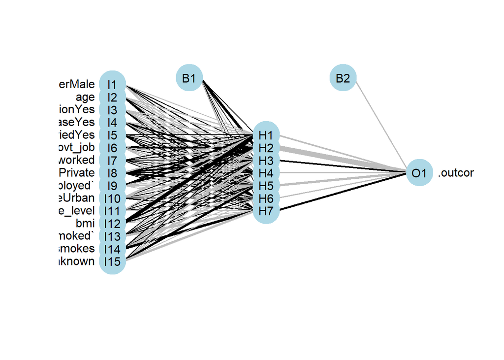

```r
plotnet(nnet_stroke$finalModel)
```

```r
#Balanced

train <- createFolds(Stroke_over$stroke, k=10)

nnet_stroke_balanced <- caret::train(stroke ~ ., method = "nnet", data = Stroke_over,
    tuneLength = 5,
    trControl = trainControl(
        method = "cv", indexOut = train),
  trace = FALSE)

nnet_stroke_balanced
```

```
## Neural Network
##
## 7520 samples
##   10 predictor
##    2 classes: 'No', 'Yes'
##
## No pre-processing
## Resampling: Cross-Validated (10 fold)
## Summary of sample sizes: 6768, 6768, 6768, 6768, 6768, 6768, ...
## Resampling results across tuning parameters:
##
##   size  decay  Accuracy   Kappa
##   1     0e+00  0.5864362  0.1728723
##   1     1e-04  0.6037234  0.2074468
##   1     1e-03  0.6046543  0.2093085
```

[output cut: 25 more lines]

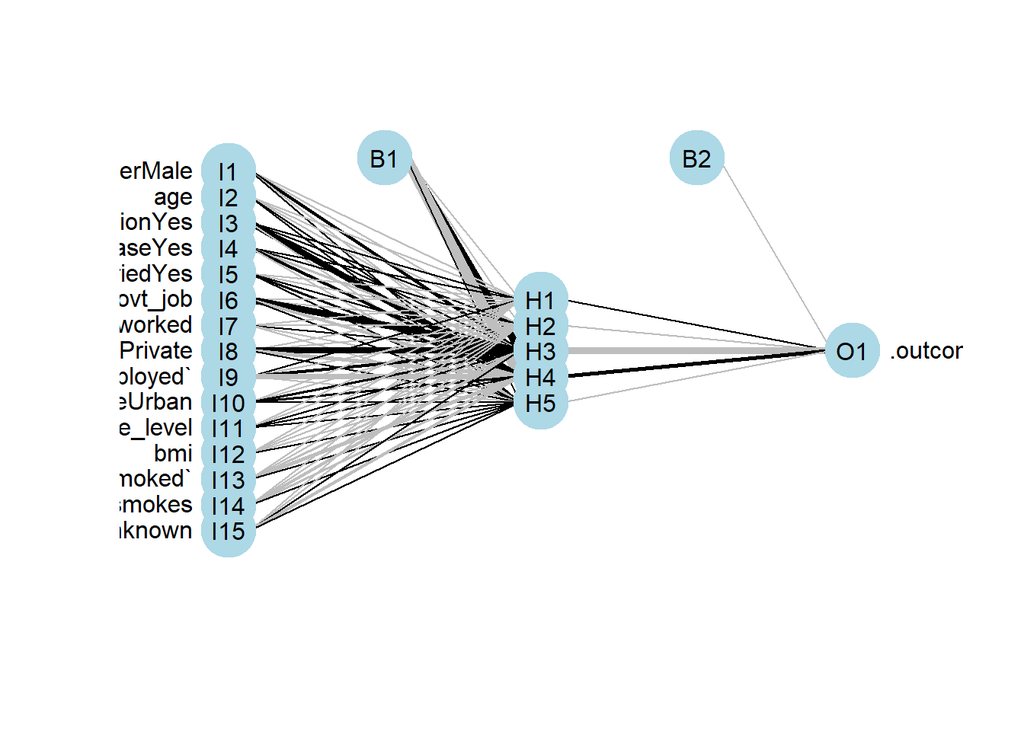

```r
plotnet(nnet_stroke_balanced$finalModel)
```

```r
#Z-Score Standardized

Stroke_tr_z_nnet <- standard.z.df(Stroke_tr)

train <- createFolds(Stroke_tr_z_nnet$stroke, k=10)


nnet_stroke_z <- caret::train(stroke ~ ., method = "nnet", data = Stroke_tr_z_nnet,
    tuneLength = 5,
    trControl = trainControl(
        method = "cv", indexOut = train),
  trace = FALSE)

nnet_stroke_z
```

```
## Neural Network
##
## 3928 samples
##   10 predictor
##    2 classes: 'No', 'Yes'
##
## No pre-processing
## Resampling: Cross-Validated (10 fold)
## Summary of sample sizes: 3535, 3536, 3535, 3536, 3535, 3535, ...
## Resampling results across tuning parameters:
##
##   size  decay  Accuracy   Kappa
##   1     0e+00  0.9572311  0.00000000
##   1     1e-04  0.9572311  0.00000000
##   1     1e-03  0.9572311  0.00000000
```

[output cut: 25 more lines]

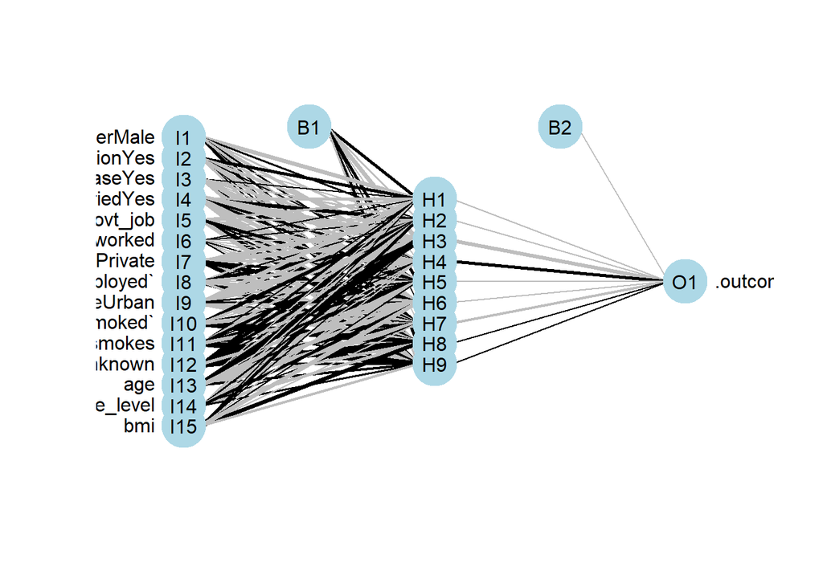

```r
plotnet(nnet_stroke_z$finalModel)
```

```r
#Z-score standardized and balanced

Stroke_tr_z_bal <- standard.z.df(Stroke_over)

train <- createFolds(Stroke_tr_z_nnet$stroke, k=10)


nnet_stroke_z_bal <- caret::train(stroke ~ ., method = "nnet", data = Stroke_over,
    tuneLength = 5,
    trControl = trainControl(
        method = "cv", indexOut = train),
  trace = FALSE)

nnet_stroke_z_bal
```

```
## Neural Network
##
## 7520 samples
##   10 predictor
##    2 classes: 'No', 'Yes'
##
## No pre-processing
## Resampling: Cross-Validated (10 fold)
## Summary of sample sizes: 6768, 6768, 6768, 6768, 6768, 6768, ...
## Resampling results across tuning parameters:
##
##   size  decay  Accuracy   Kappa
##   1     0e+00  0.4454815  0.02623893
##   1     1e-04  0.5165609  0.02011860
##   1     1e-03  0.5445085  0.03335283
```

[output cut: 25 more lines]

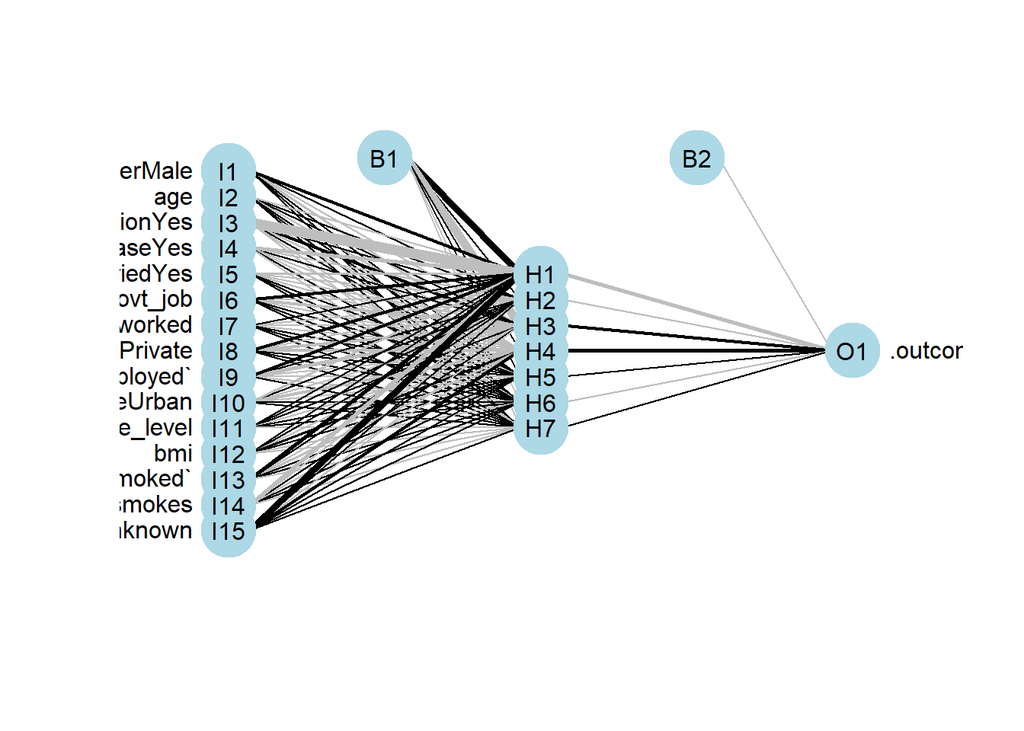

```r
plotnet(nnet_stroke_z_bal$finalModel)
```

### Evaluate NN

```r
nnet_reg <- confusionMatrix(data = predict(nnet_stroke, Stroke_test), ref = Stroke_test$stroke, positive = "Yes")
nnet_reg
```

```
## Confusion Matrix and Statistics
##
##           Reference
## Prediction  No Yes
##        No  939  41
##        Yes   0   0
##
##                Accuracy : 0.9582
##                  95% CI : (0.9437, 0.9698)
##     No Information Rate : 0.9582
##     P-Value [Acc > NIR] : 0.5414
##
##                   Kappa : 0
##
##  Mcnemar's Test P-Value : 4.185e-10
##
##             Sensitivity : 0.00000
##             Specificity : 1.00000
##          Pos Pred Value :     NaN
##          Neg Pred Value : 0.95816
##              Prevalence : 0.04184
##          Detection Rate : 0.00000
##    Detection Prevalence : 0.00000
##       Balanced Accuracy : 0.50000
##
##        'Positive' Class : Yes
##
```

```r
nnet_bal <- confusionMatrix(data = predict(nnet_stroke_balanced, Stroke_test), ref = Stroke_test$stroke, positive = "Yes")
nnet_bal
```

```
## Confusion Matrix and Statistics
##
##           Reference
## Prediction  No Yes
##        No  712   7
##        Yes 227  34
##
##                Accuracy : 0.7612
##                  95% CI : (0.7333, 0.7876)
##     No Information Rate : 0.9582
##     P-Value [Acc > NIR] : 1
##
##                   Kappa : 0.1648
##
##  Mcnemar's Test P-Value : <2e-16
##
##             Sensitivity : 0.82927
##             Specificity : 0.75825
##          Pos Pred Value : 0.13027
##          Neg Pred Value : 0.99026
##              Prevalence : 0.04184
##          Detection Rate : 0.03469
##    Detection Prevalence : 0.26633
##       Balanced Accuracy : 0.79376
##
##        'Positive' Class : Yes
##
```

```r
nnet_z <- confusionMatrix(data = predict(nnet_stroke_z, Stroke_test), ref = Stroke_test$stroke, positive = "Yes")
nnet_z
```

```
## Confusion Matrix and Statistics
##
##           Reference
## Prediction  No Yes
##        No  939  41
##        Yes   0   0
##
##                Accuracy : 0.9582
##                  95% CI : (0.9437, 0.9698)
##     No Information Rate : 0.9582
##     P-Value [Acc > NIR] : 0.5414
##
##                   Kappa : 0
##
##  Mcnemar's Test P-Value : 4.185e-10
##
##             Sensitivity : 0.00000
##             Specificity : 1.00000
##          Pos Pred Value :     NaN
##          Neg Pred Value : 0.95816
##              Prevalence : 0.04184
##          Detection Rate : 0.00000
##    Detection Prevalence : 0.00000
##       Balanced Accuracy : 0.50000
##
##        'Positive' Class : Yes
##
```

```r
nnet_z_bal <- confusionMatrix(data = predict(nnet_stroke_z_bal, Stroke_test), ref = Stroke_test$stroke, positive = "Yes")
nnet_z_bal
```

```
## Confusion Matrix and Statistics
##
##           Reference
## Prediction  No Yes
##        No  697   5
##        Yes 242  36
##
##                Accuracy : 0.748
##                  95% CI : (0.7195, 0.7749)
##     No Information Rate : 0.9582
##     P-Value [Acc > NIR] : 1
##
##                   Kappa : 0.1648
##
##  Mcnemar's Test P-Value : <2e-16
##
##             Sensitivity : 0.87805
##             Specificity : 0.74228
##          Pos Pred Value : 0.12950
##          Neg Pred Value : 0.99288
##              Prevalence : 0.04184
##          Detection Rate : 0.03673
##    Detection Prevalence : 0.28367
##       Balanced Accuracy : 0.81016
##
##        'Positive' Class : Yes
##
```

# Model Evaluation

## Add Baseline

```r
Stroke_count <- Stroke_test %>% group_by(stroke) %>% tally()
Stroke_count
```

```
## # A tibble: 2 x 2
##   stroke     n
##   <fct>  <int>
## 1 No       939
## 2 Yes       41
```

```r
TN <- as.numeric(Stroke_count[1,2])
FN <- as.numeric(Stroke_count[2,2])
TP <- 0
FP <- 0

Accuracy_base <- TN/(TN+FN)
Sensitivity_base <- TP/(TP+FN)
Specificity_base<- TN/(TN+FP)
Precision_base <- TP/(TP+FP)
F1_base <- 0

Baseline <- c(Accuracy_base, Sensitivity_base, Specificity_base, Precision_base, F1_base)
```

## Model Comparison Data Frame

```r
#Models
"ANN Reg." <- c(nnet_reg$overall, nnet_reg$byClass)
"ANN Bal." <- c(nnet_bal$overall, nnet_bal$byClass)
"ANN Z" <- c(nnet_z$overall, nnet_z$byClass)
"ANN Z Bal." <- c(nnet_z_bal$overall, nnet_z_bal$byClass)
"RF Reg." <- c(rf_reg$overall, rf_reg$byClass)
"RF Bal." <- c(rf_bal$overall, rf_bal$byClass)
"CART Bal." <- c(cart_bal$overall, cart_bal$byClass)
"C5.0 Bal." <- c(C5_bal$overall, C5_bal$byClass)
"NB Gender" <- c(nb_gender$overall, nb_gender$byClass)
"NB Heart + Marry" <- c(nb_heart_marry$overall, nb_heart_marry$byClass)
"NB Resident" <- c(nb_Res$overall, nb_Res$byClass)
"NB Smoke + Work" <- c(nb_smoke_work$overall, nb_smoke_work$byClass)
"CART Cost" <- c(cart_cost$overall, cart_cost$byClass)
"CART Cost Bal." <- c(cart_cost_bal$overall, cart_cost_bal$byClass)

#Get LogReg Model
LogReg <- pivot_wider(eval.dflr, values_from = model.lr, names_from = eval.measure)
colnames(LogReg) <- str_to_title(colnames(LogReg))
LogReg <- LogReg %>% dplyr::select(Accuracy, Sensitivity, Specificity, Precision, F1)


Model_comp <- rbind(`ANN Reg.`, `ANN Bal.`, `ANN Z`, `ANN Z Bal.`, `RF Reg.`, `RF Bal.`, `CART Bal.`, `CART Cost`, `CART Cost Bal.`, `C5.0 Bal.`, `NB Gender`, `NB Heart + Marry`, `NB Resident`, `NB Smoke + Work`)
Model_comp <- data.frame(Model_comp)

Model_comp <- Model_comp %>% dplyr::select(Accuracy, Sensitivity, Specificity, Precision, F1)

Model_comp <- rbind(Baseline, LogReg, Model_comp)

rownames(Model_comp)[rownames(Model_comp) == 1] <- "Baseline"
rownames(Model_comp)[rownames(Model_comp) == 2] <- "Log Reg."
Model_comp <- cbind(Model = rownames(Model_comp), Model_comp)
rownames(Model_comp) <- 1:nrow(Model_comp)

Model_comp$Model <- as.factor(Model_comp$Model)
Model_comp[is.na(Model_comp)] <- 0
```

## Accuracy Graph

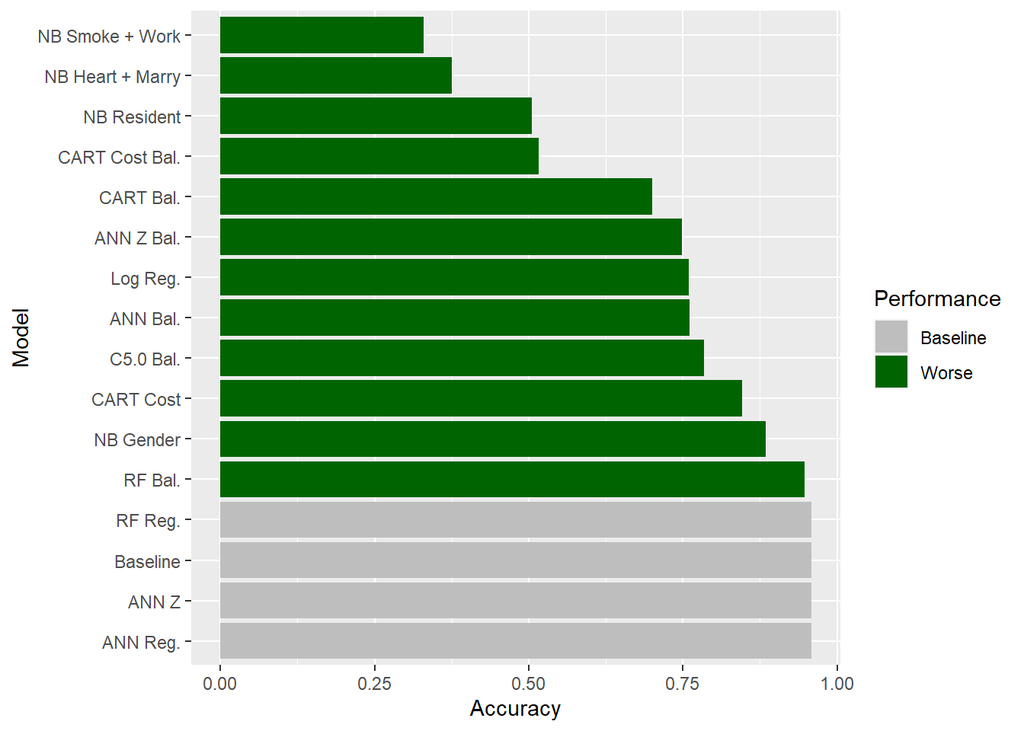

```r
Model_comp %>% mutate(Model = fct_reorder(Model, desc(Accuracy))) %>% mutate(Performance = ifelse(Model_comp$Accuracy == Accuracy_base, "Baseline", ifelse(Model_comp$Accuracy < Accuracy_base, "Worse", "Better"))) %>% ggplot(aes(x=Model, y=Accuracy, fill = Performance)) + geom_bar(stat = "identity") + coord_flip() + scale_fill_manual(values = c("grey", "darkgreen", "#c12503"))
```

## Sensitivity

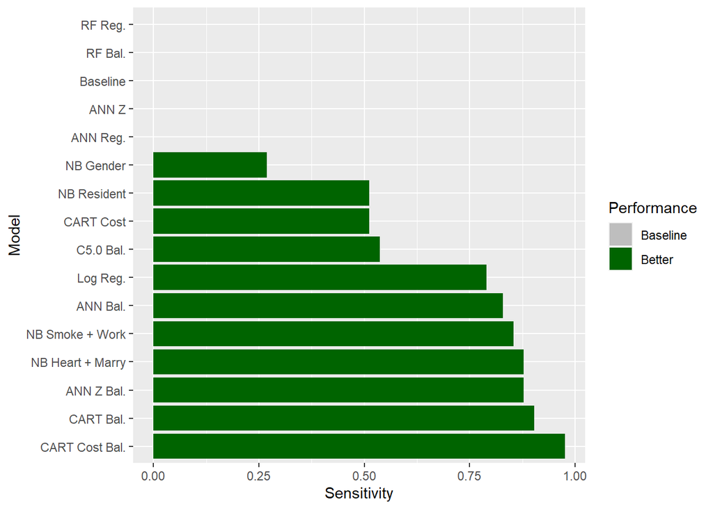

```r
Model_comp %>% mutate(Model = fct_reorder(Model, desc(Sensitivity))) %>% mutate(Performance = ifelse(Model_comp$Sensitivity == Sensitivity_base, "Baseline", ifelse(Model_comp$Sensitivity < Sensitivity_base, "Worse", "Better"))) %>%
  ggplot(aes(x=Model, y=Sensitivity, fill = Performance)) + geom_bar(stat = "identity") + coord_flip() + scale_fill_manual(values = c("Grey", "darkgreen"))
```

## Specificity

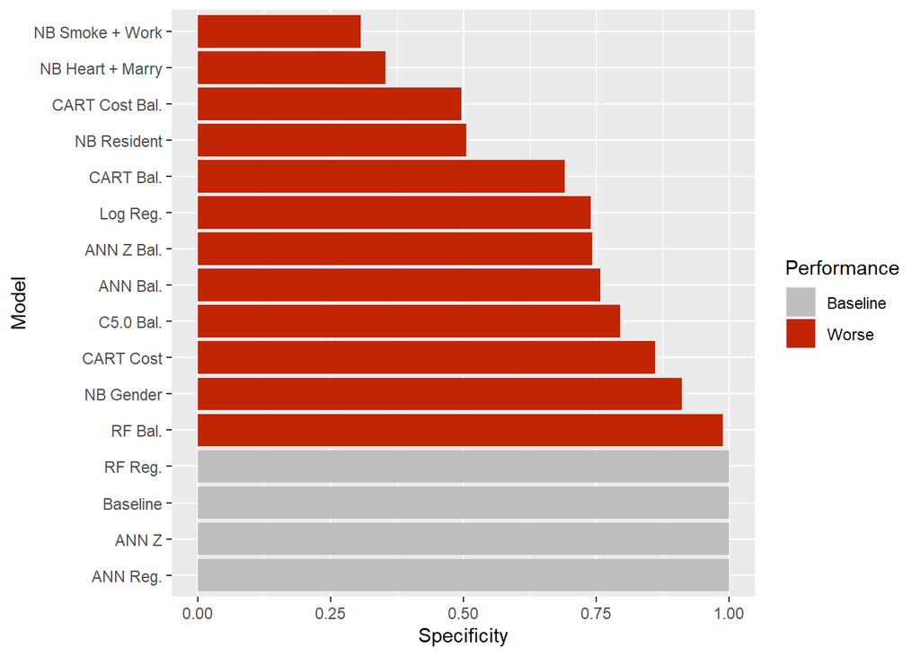

```r
Model_comp %>% mutate(Model = fct_reorder(Model, desc(Specificity))) %>% mutate(Performance = ifelse(Model_comp$Specificity == Specificity_base, "Baseline", ifelse(Model_comp$Specificity < Specificity_base, "Worse", "Better"))) %>%
  ggplot(aes(x=Model, y=Specificity, fill = Performance)) + geom_bar(stat = "identity") + coord_flip() + scale_fill_manual(values = c("Grey", "#c12503"))
```

## Precision

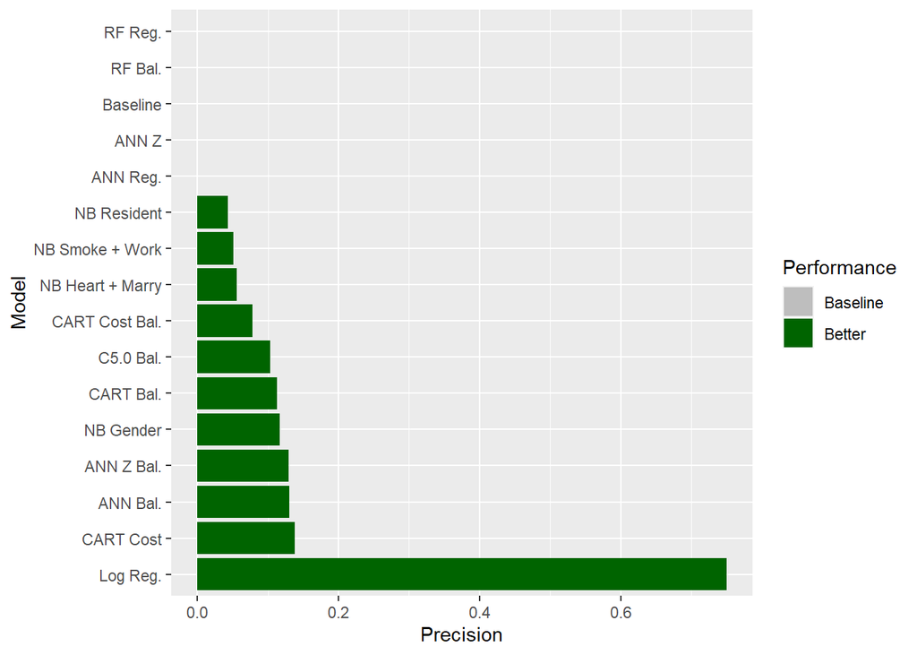

```r
Model_comp %>% mutate(Model = fct_reorder(Model, desc(Precision))) %>% mutate(Performance = ifelse(Model_comp$Precision == 0, "Baseline", ifelse(Model_comp$Precision < 0, "Worse", "Better"))) %>% ggplot(aes(x=Model, y=Precision, fill = Performance)) + geom_bar(stat = "identity") + coord_flip() + scale_fill_manual(values = c("Grey", "darkgreen"))
```

## F1

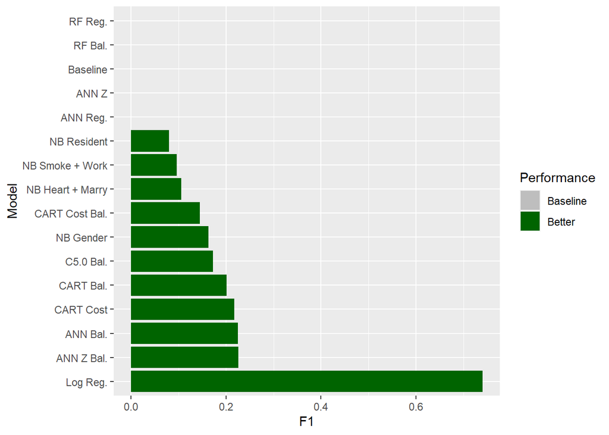

```r
Model_comp %>% mutate(Model = fct_reorder(Model, desc(F1))) %>% mutate(Performance = ifelse(Model_comp$F1 == F1_base, "Baseline", ifelse(Model_comp$F1 < F1_base, "Worse", "Better"))) %>%
  ggplot(aes(x=Model, y=F1, fill = Performance)) + geom_bar(stat = "identity") + coord_flip() + scale_fill_manual(values = c("Grey", "darkgreen"))
```

## Comparison Table

```r
kable(Model_comp, table.attr = "style = \"color: black;\"") %>% kable_material(c("striped", "hover")) %>% column_spec(1, bold = T, border_right = T)
```

| Model | Accuracy | Sensitivity | Specificity | Precision | F1 |
| --- | --- | --- | --- | --- | --- |
| Baseline | 0.9581633 | 0.0000000 | 1.0000000 | 0.0000000 | 0.0000000 |
| Log Reg. | 0.7600000 | 0.7900000 | 0.7400000 | 0.7500000 | 0.7400000 |
| ANN Reg. | 0.9581633 | 0.0000000 | 1.0000000 | 0.0000000 | 0.0000000 |
| ANN Bal. | 0.7612245 | 0.8292683 | 0.7582535 | 0.1302682 | 0.2251656 |
| ANN Z | 0.9581633 | 0.0000000 | 1.0000000 | 0.0000000 | 0.0000000 |
| ANN Z Bal. | 0.7479592 | 0.8780488 | 0.7422790 | 0.1294964 | 0.2257053 |
| RF Reg. | 0.9581633 | 0.0000000 | 1.0000000 | 0.0000000 | 0.0000000 |
| RF Bal. | 0.9479592 | 0.0000000 | 0.9893504 | 0.0000000 | 0.0000000 |
| CART Bal. | 0.7000000 | 0.9024390 | 0.6911608 | 0.1131498 | 0.2010870 |
| CART Cost | 0.8459184 | 0.5121951 | 0.8604899 | 0.1381579 | 0.2176166 |
| CART Cost Bal. | 0.5163265 | 0.9756098 | 0.4962726 | 0.0779727 | 0.1444043 |
| C5.0 Bal. | 0.7846939 | 0.5365854 | 0.7955272 | 0.1028037 | 0.1725490 |
| NB Gender | 0.8846939 | 0.2682927 | 0.9116081 | 0.1170213 | 0.1629630 |
| NB Heart + Marry | 0.3755102 | 0.8780488 | 0.3535676 | 0.0559876 | 0.1052632 |
| NB Resident | 0.5051020 | 0.5121951 | 0.5047923 | 0.0432099 | 0.0796964 |
| NB Smoke + Work | 0.3295918 | 0.8536585 | 0.3067093 | 0.0510204 | 0.0962861 |